# algaeBlossoms

Deep Amlani

2/20/2019

Predicting when does the algae blossoms algaeDataset is our Dataset name

```r
#install.packages('DMwR')
library(DMwR)
algaeDataset <- algae
```

From the below summary we can observe that during the winter season maximum water samples has been taken, also from the chemical parameters summary we undertand that we have some NA’s value

```r
summary(algaeDataset)
```

```
##     season       size       speed         mxPH            mnO2
##  autumn:40   large :45   high  :84   Min.   :5.600   Min.   : 1.500
##  spring:53   medium:84   low   :33   1st Qu.:7.700   1st Qu.: 7.725
##  summer:45   small :71   medium:83   Median :8.060   Median : 9.800
##  winter:62                           Mean   :8.012   Mean   : 9.118
##                                      3rd Qu.:8.400   3rd Qu.:10.800
##                                      Max.   :9.700   Max.   :13.400
##                                      NA's   :1       NA's   :2
##        Cl               NO3              NH4                oPO4
##  Min.   :  0.222   Min.   : 0.050   Min.   :    5.00   Min.   :  1.00
##  1st Qu.: 10.981   1st Qu.: 1.296   1st Qu.:   38.33   1st Qu.: 15.70
##  Median : 32.730   Median : 2.675   Median :  103.17   Median : 40.15
##  Mean   : 43.636   Mean   : 3.282   Mean   :  501.30   Mean   : 73.59
##  3rd Qu.: 57.824   3rd Qu.: 4.446   3rd Qu.:  226.95   3rd Qu.: 99.33
##  Max.   :391.500   Max.   :45.650   Max.   :24064.00   Max.   :564.60
##  NA's   :10        NA's   :2        NA's   :2          NA's   :2
##       PO4              Chla               a1              a2
##  Min.   :  1.00   Min.   :  0.200   Min.   : 0.00   Min.   : 0.000
##  1st Qu.: 41.38   1st Qu.:  2.000   1st Qu.: 1.50   1st Qu.: 0.000
##  Median :103.29   Median :  5.475   Median : 6.95   Median : 3.000
##  Mean   :137.88   Mean   : 13.971   Mean   :16.92   Mean   : 7.458
##  3rd Qu.:213.75   3rd Qu.: 18.308   3rd Qu.:24.80   3rd Qu.:11.375
##  Max.   :771.60   Max.   :110.456   Max.   :89.80   Max.   :72.600
##  NA's   :2        NA's   :12
##        a3               a4               a5               a6
##  Min.   : 0.000   Min.   : 0.000   Min.   : 0.000   Min.   : 0.000
##  1st Qu.: 0.000   1st Qu.: 0.000   1st Qu.: 0.000   1st Qu.: 0.000
##  Median : 1.550   Median : 0.000   Median : 1.900   Median : 0.000
##  Mean   : 4.309   Mean   : 1.992   Mean   : 5.064   Mean   : 5.964
##  3rd Qu.: 4.925   3rd Qu.: 2.400   3rd Qu.: 7.500   3rd Qu.: 6.925
##  Max.   :42.800   Max.   :44.600   Max.   :44.400   Max.   :77.600
##
##        a7
##  Min.   : 0.000
##  1st Qu.: 0.000
##  Median : 1.000
##  Mean   : 2.495
##  3rd Qu.: 2.400
##  Max.   :31.600
##
```

Removing the NA from the dataset

```r
algaeDataset <- na.omit(algaeDataset)
summary(algaeDataset)
```

```
##     season       size       speed         mxPH            mnO2
##  autumn:36   large :42   high  :76   Min.   :7.000   Min.   : 1.500
##  spring:48   medium:83   low   :31   1st Qu.:7.777   1st Qu.: 7.675
##  summer:43   small :59   medium:77   Median :8.100   Median : 9.750
##  winter:57                           Mean   :8.078   Mean   : 9.019
##                                      3rd Qu.:8.400   3rd Qu.:10.700
##                                      Max.   :9.500   Max.   :13.400
##        Cl              NO3              NH4                oPO4
##  Min.   :  0.80   Min.   : 0.050   Min.   :    5.80   Min.   :  1.25
##  1st Qu.: 11.85   1st Qu.: 1.364   1st Qu.:   49.38   1st Qu.: 18.56
##  Median : 35.08   Median : 2.820   Median :  115.71   Median : 46.28
##  Mean   : 44.88   Mean   : 3.384   Mean   :  537.67   Mean   : 78.27
##  3rd Qu.: 58.52   3rd Qu.: 4.540   3rd Qu.:  235.25   3rd Qu.:102.83
##  Max.   :391.50   Max.   :45.650   Max.   :24064.00   Max.   :564.60
##       PO4              Chla               a1              a2
##  Min.   :  2.50   Min.   :  0.200   Min.   : 0.00   Min.   : 0.000
##  1st Qu.: 50.34   1st Qu.:  2.075   1st Qu.: 1.40   1st Qu.: 0.000
##  Median :115.60   Median :  5.522   Median : 4.85   Median : 3.600
##  Mean   :146.58   Mean   : 13.883   Mean   :15.32   Mean   : 7.777
##  3rd Qu.:220.25   3rd Qu.: 18.308   3rd Qu.:19.32   3rd Qu.:11.700
##  Max.   :771.60   Max.   :110.456   Max.   :89.80   Max.   :72.600
##        a3               a4               a5               a6
##  Min.   : 0.000   Min.   : 0.000   Min.   : 0.000   Min.   : 0.000
##  1st Qu.: 0.000   1st Qu.: 0.000   1st Qu.: 0.000   1st Qu.: 0.000
##  Median : 1.700   Median : 0.000   Median : 2.650   Median : 0.000
##  Mean   : 4.613   Mean   : 1.846   Mean   : 5.493   Mean   : 6.447
##  3rd Qu.: 5.525   3rd Qu.: 2.425   3rd Qu.: 8.000   3rd Qu.: 7.975
##  Max.   :42.800   Max.   :44.600   Max.   :44.400   Max.   :77.600
##        a7
##  Min.   : 0.000
##  1st Qu.: 0.000
##  Median : 1.000
##  Mean   : 2.665
##  3rd Qu.: 2.700
##  Max.   :31.600
```

# Visualizing the algae blossoms

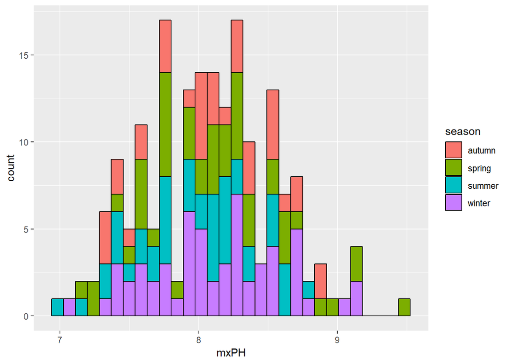

```r
library(ggplot2)
ggplot(algaeDataset,aes(mxPH,fill = season)) + geom_histogram(colour = "black")
```

As we can see from the boxplot, we have a lot of outliers thus concluding that these values must have a lot of effect on the orthophoshate chemical count of the river

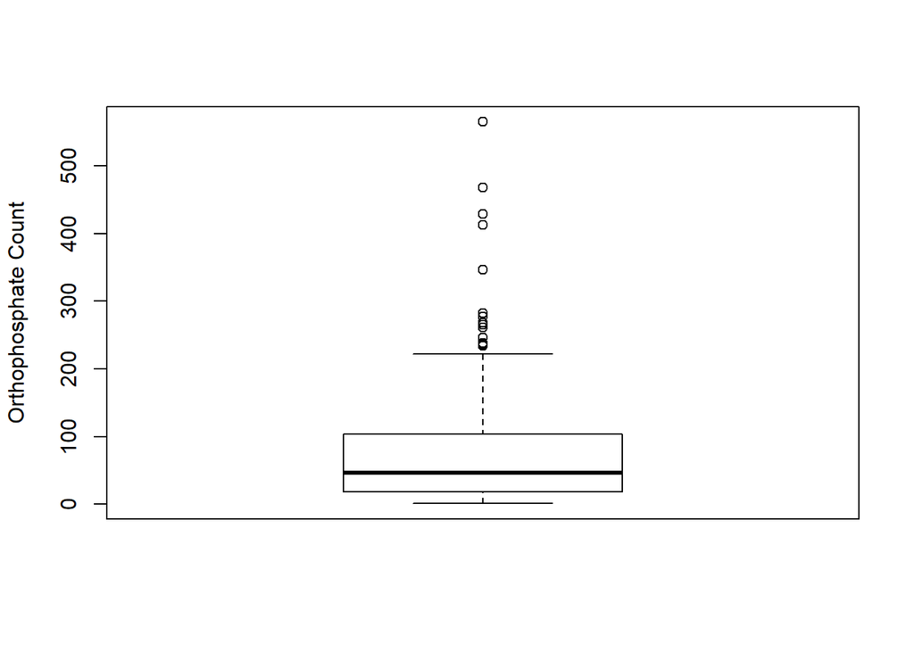

```r
boxplot(algaeDataset$oPO4, ylab="Orthophosphate Count")
```

As we can see from the below graph that maximum times when the size of the river is medium we have taken the samples to identify the algae blossoms

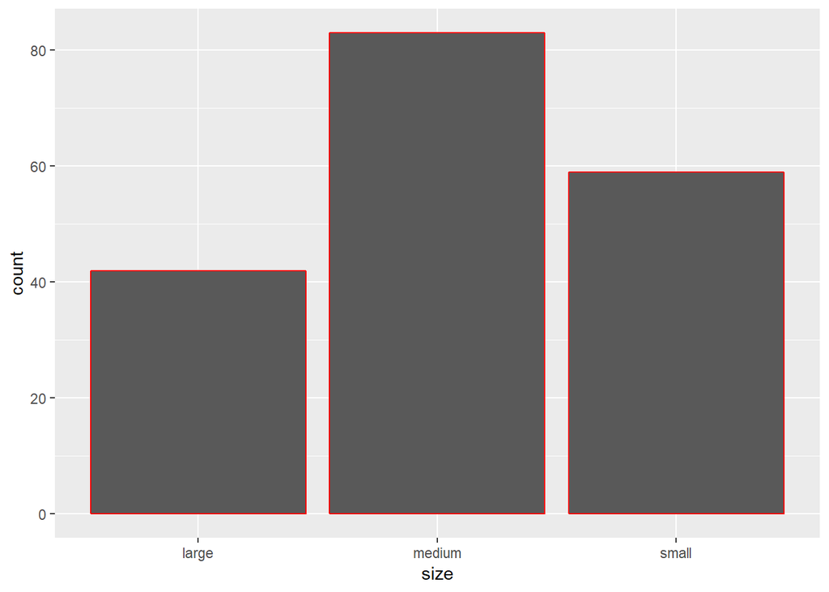

```r
ggplot(algaeDataset,aes(x=size)) + geom_bar(colour = "Red")
```

Here we are doing a bivariate boxplot which is helping us to understand about algae 1 that in what kind of the size of the river does it blossom more, so here we say that when the river size is small algae 1 blossoms a lot and we also see lot of outliers river size is medium

```r
#install.packages('lattice')
#install.packages('Hmisc')
library(lattice)
library(Hmisc)
```

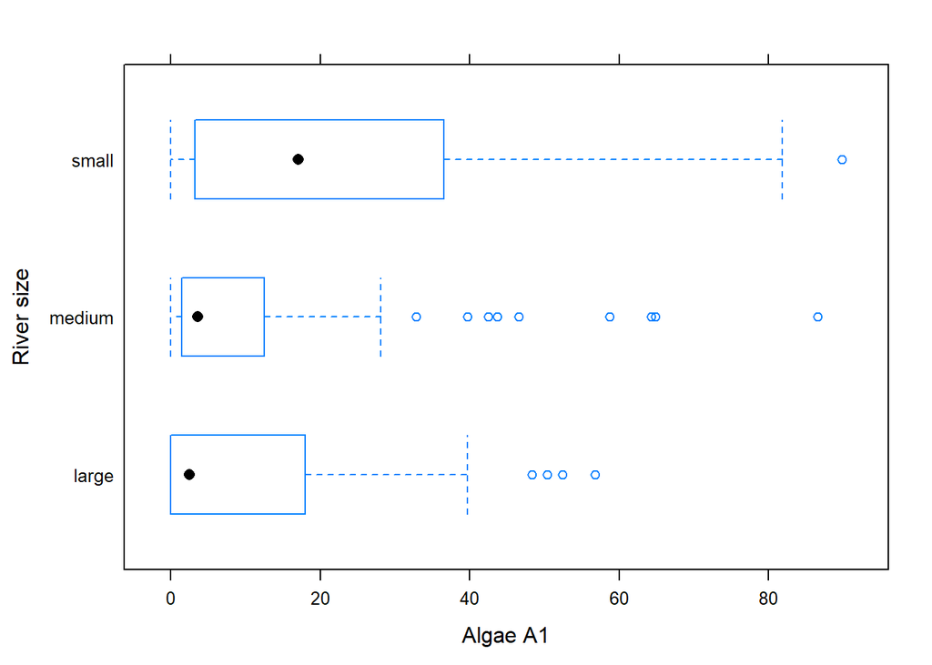

```r
bwplot(size~a1,data=algaeDataset,xlab = "Algae A1",ylab = "River size")
```

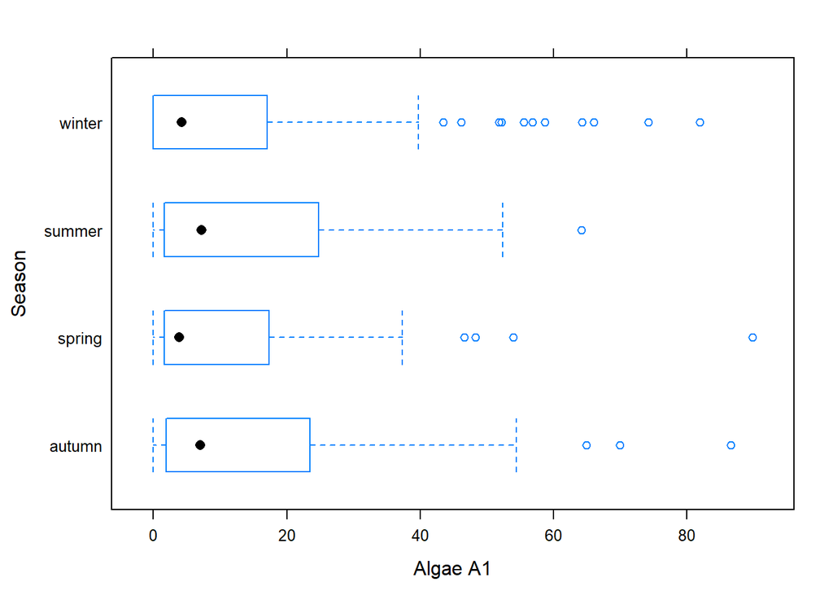

```r
bwplot(season~a1,data=algaeDataset,xlab = "Algae A1",ylab = "Season")
```

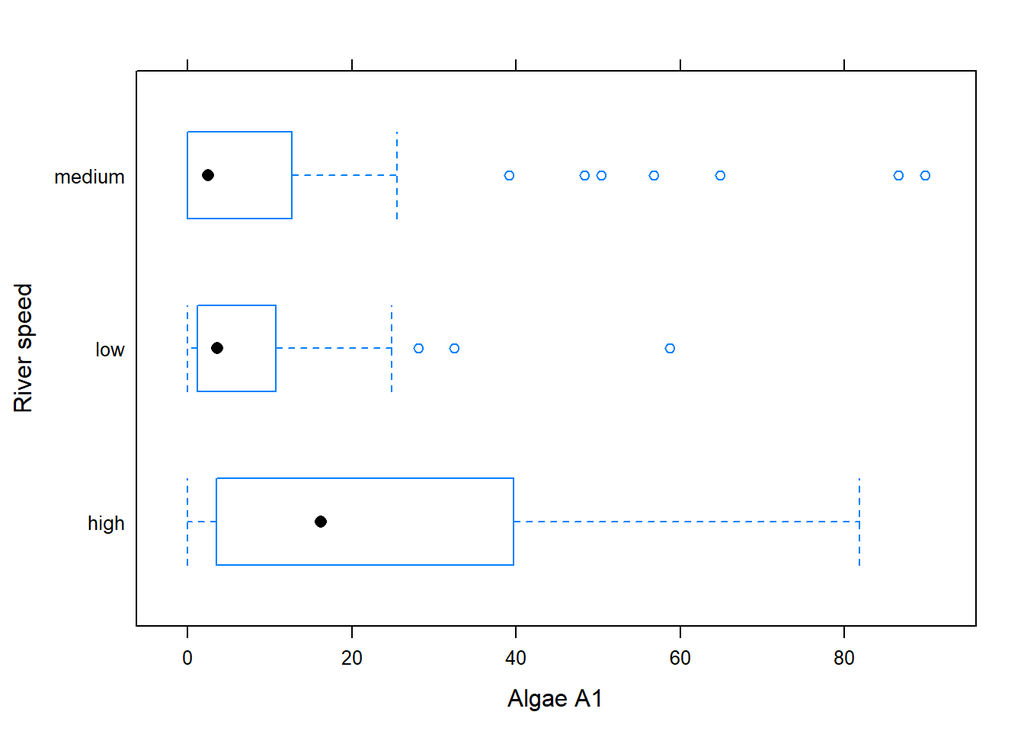

```r
bwplot(speed~a1,data=algaeDataset,xlab = "Algae A1",ylab = "River speed")
```

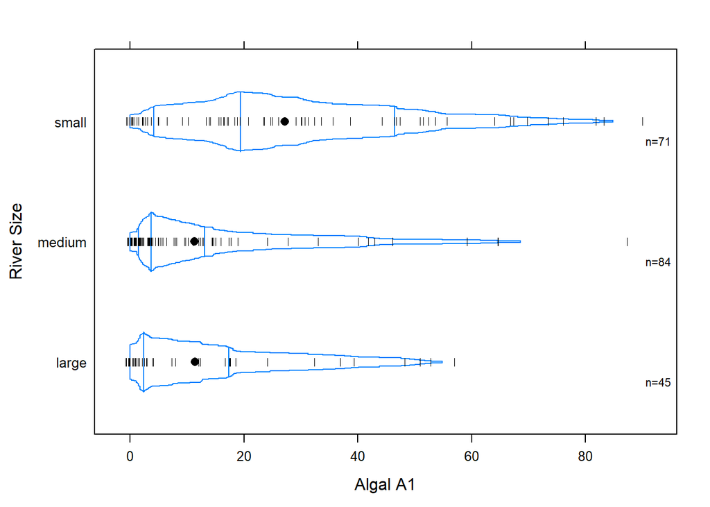

```r
bwplot(size ~ a1,data=algae,panel=panel.bpplot,probs=seq(.01,.49,by=.01),datadensity=TRUE,ylab='River Size',xlab='Algal A1')
```

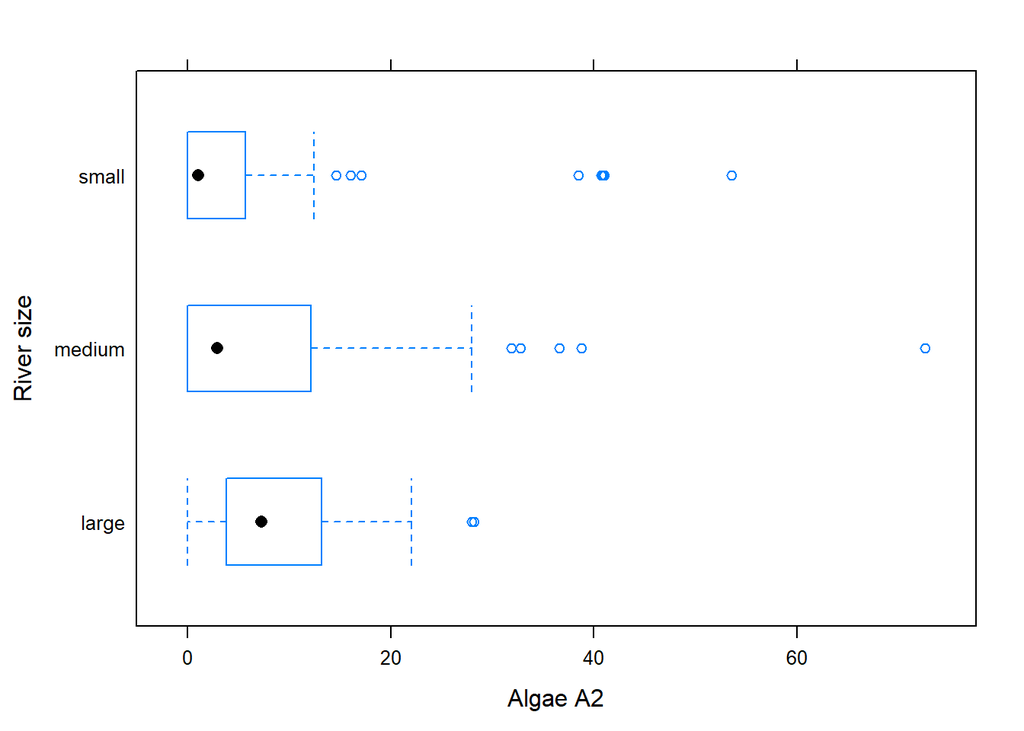

```r
bwplot(size~a2,data=algaeDataset,xlab = "Algae A2",ylab = "River size")
```

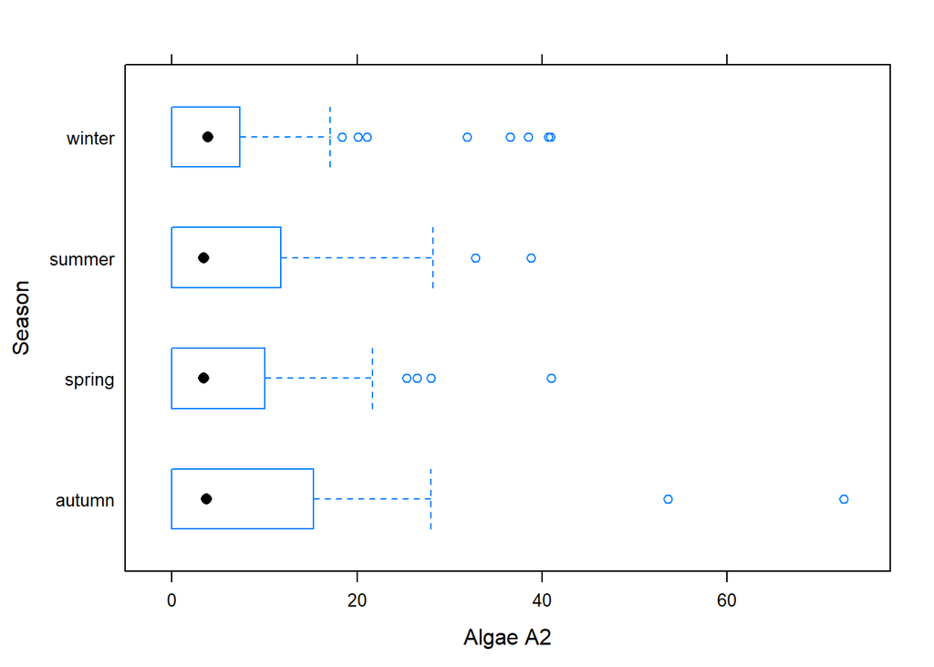

```r
bwplot(season~a2,data=algaeDataset,xlab = "Algae A2",ylab = "Season")
```

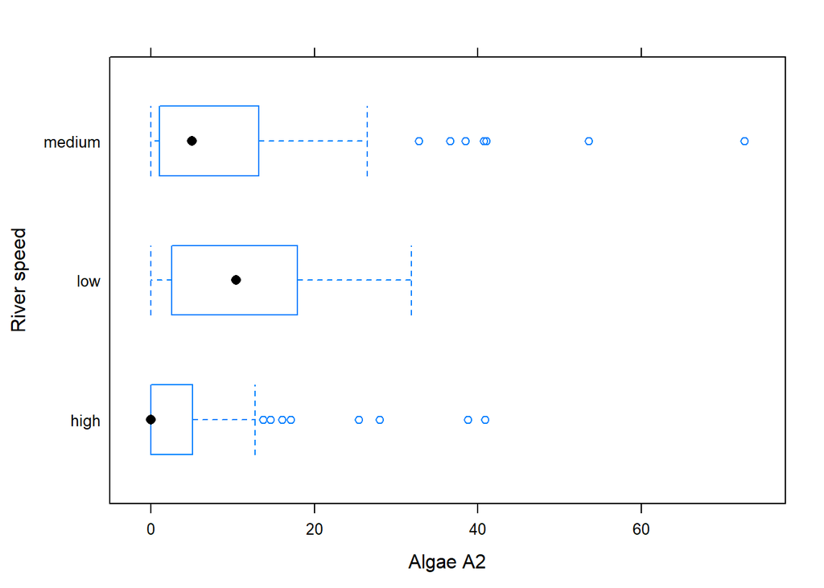

```r
bwplot(speed~a2,data=algaeDataset,xlab = "Algae A2",ylab = "River speed")
```

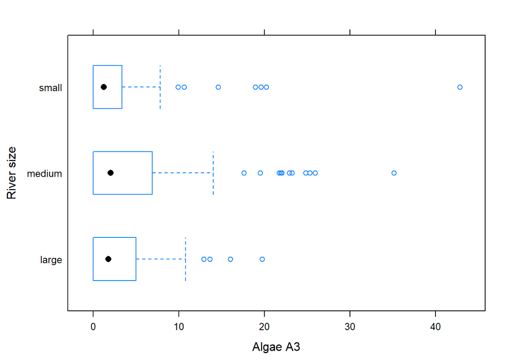

```r
bwplot(size~a3,data=algaeDataset,xlab = "Algae A3",ylab = "River size")
```

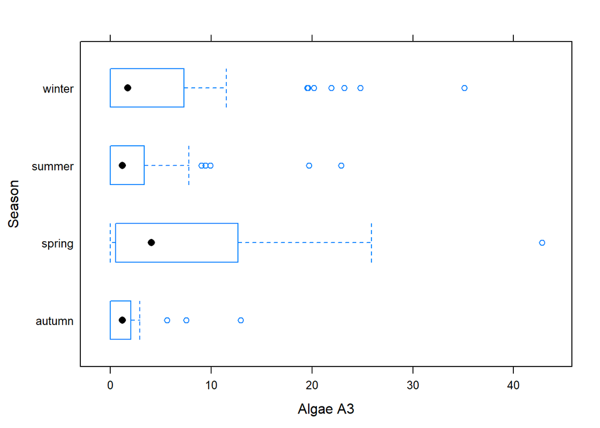

```r
bwplot(season~a3,data=algaeDataset,xlab = "Algae A3",ylab = "Season")
```

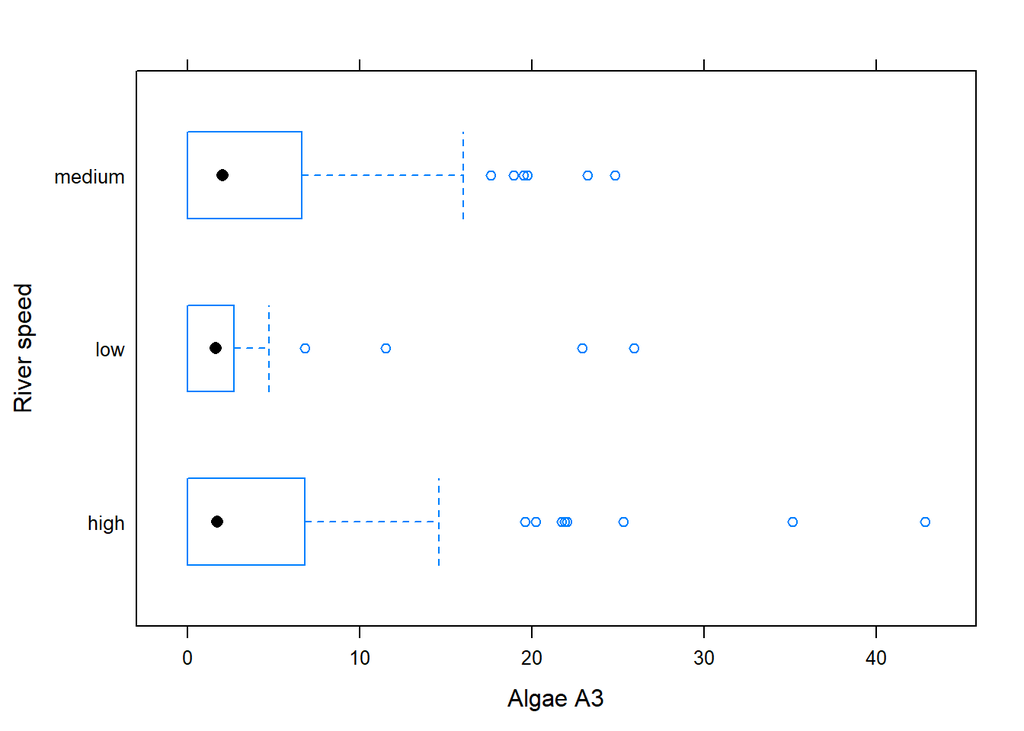

```r
bwplot(speed~a3,data=algaeDataset,xlab = "Algae A3",ylab = "River speed")
```

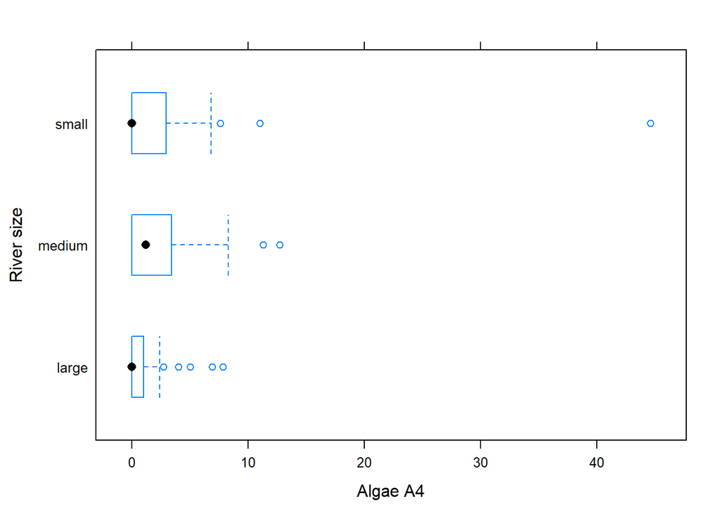

```r
bwplot(size~a4,data=algaeDataset,xlab = "Algae A4",ylab = "River size")
```

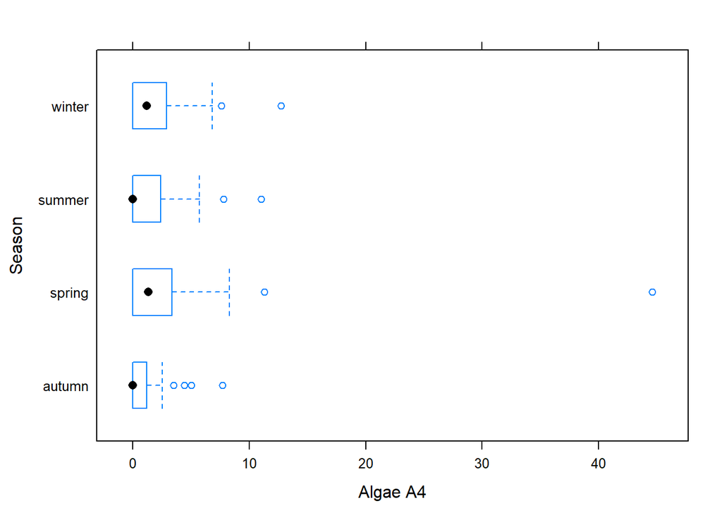

```r
bwplot(season~a4,data=algaeDataset,xlab = "Algae A4",ylab = "Season")
```

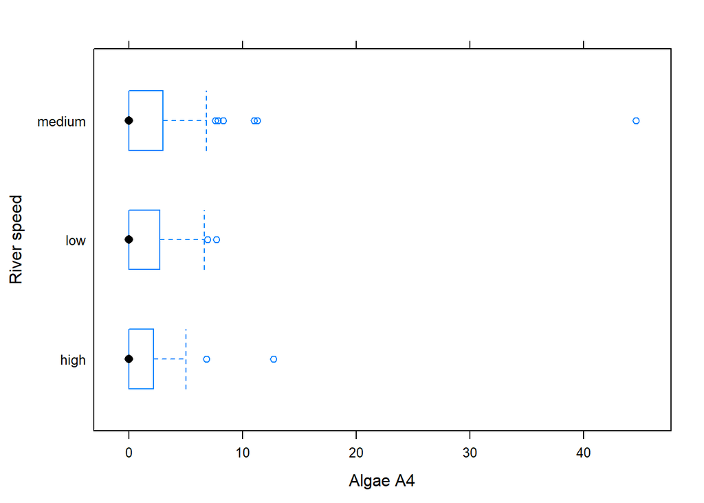

```r
bwplot(speed~a4,data=algaeDataset,xlab = "Algae A4",ylab = "River speed")
```

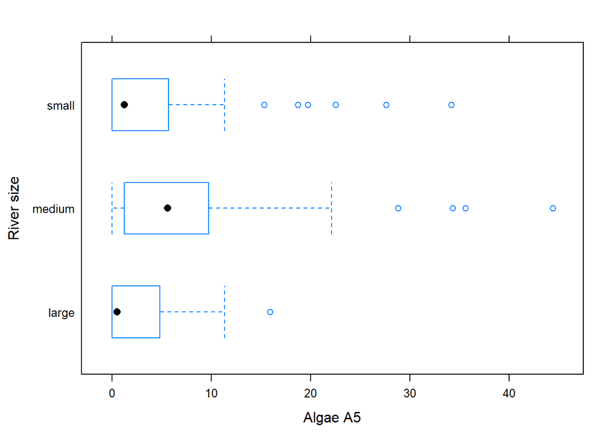

```r
bwplot(size~a5,data=algaeDataset,xlab = "Algae A5",ylab = "River size")
```

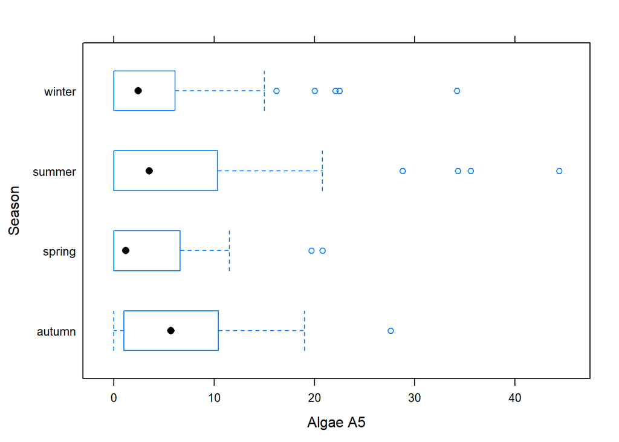

```r
bwplot(season~a5,data=algaeDataset,xlab = "Algae A5",ylab = "Season")
```

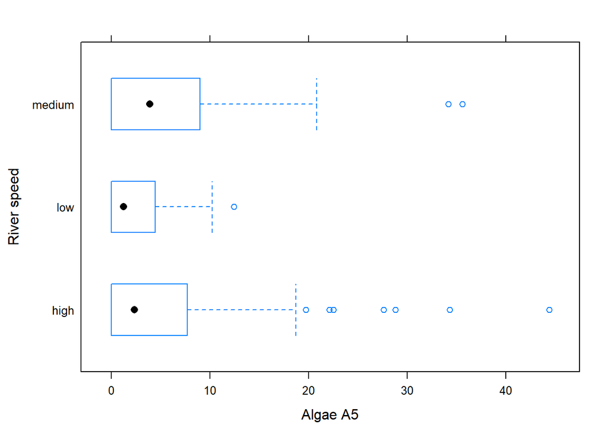

```r
bwplot(speed~a5,data=algaeDataset,xlab = "Algae A5",ylab = "River speed")
```

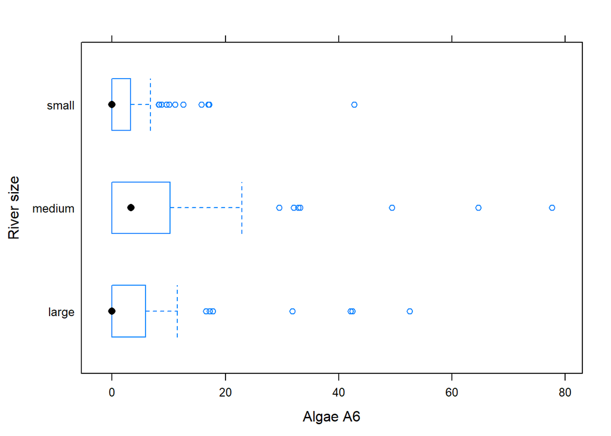

```r
bwplot(size~a6,data=algaeDataset,xlab = "Algae A6",ylab = "River size")
```

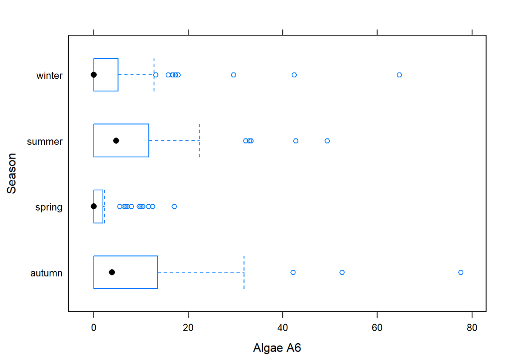

```r
bwplot(season~a6,data=algaeDataset,xlab = "Algae A6",ylab = "Season")
```

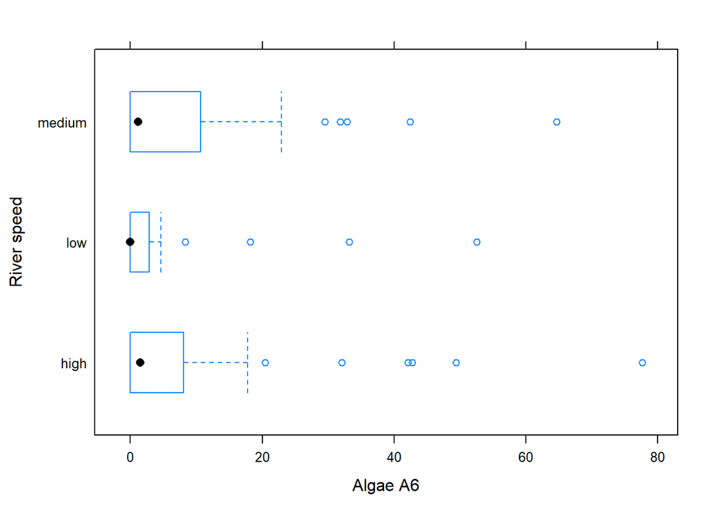

```r
bwplot(speed~a6,data=algaeDataset,xlab = "Algae A6",ylab = "River speed")
```

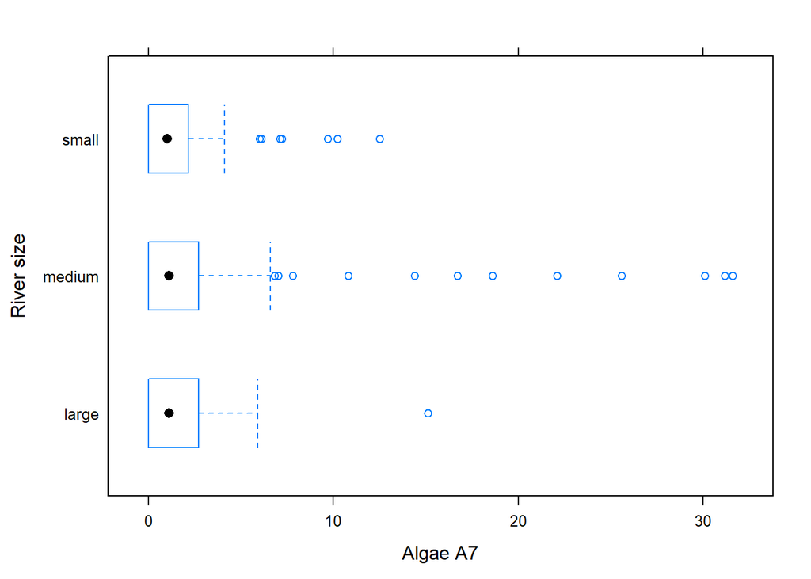

```r
bwplot(size~a7,data=algaeDataset,xlab = "Algae A7",ylab = "River size")
```

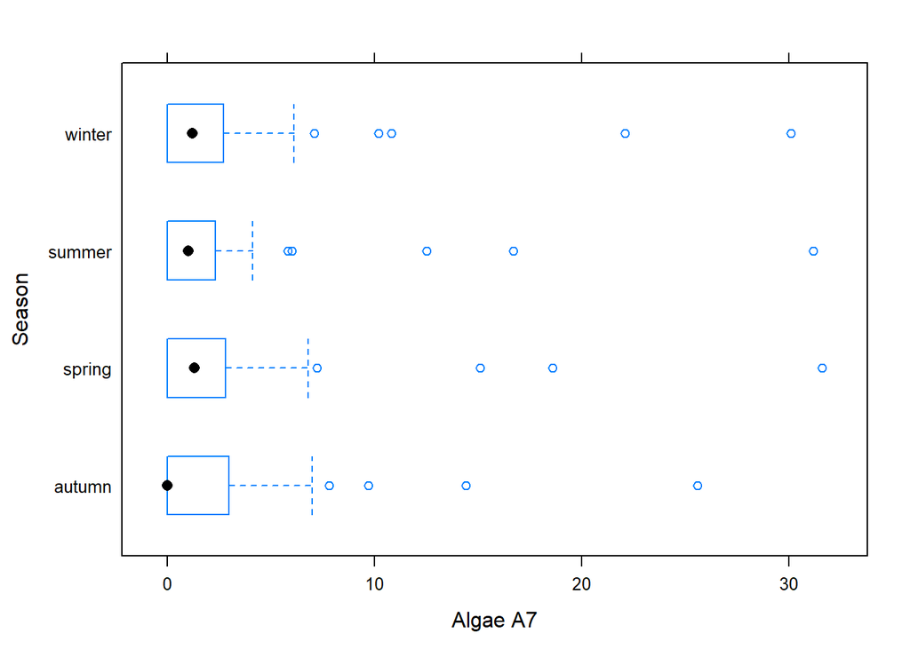

```r
bwplot(season~a7,data=algaeDataset,xlab = "Algae A7",ylab = "Season")
```

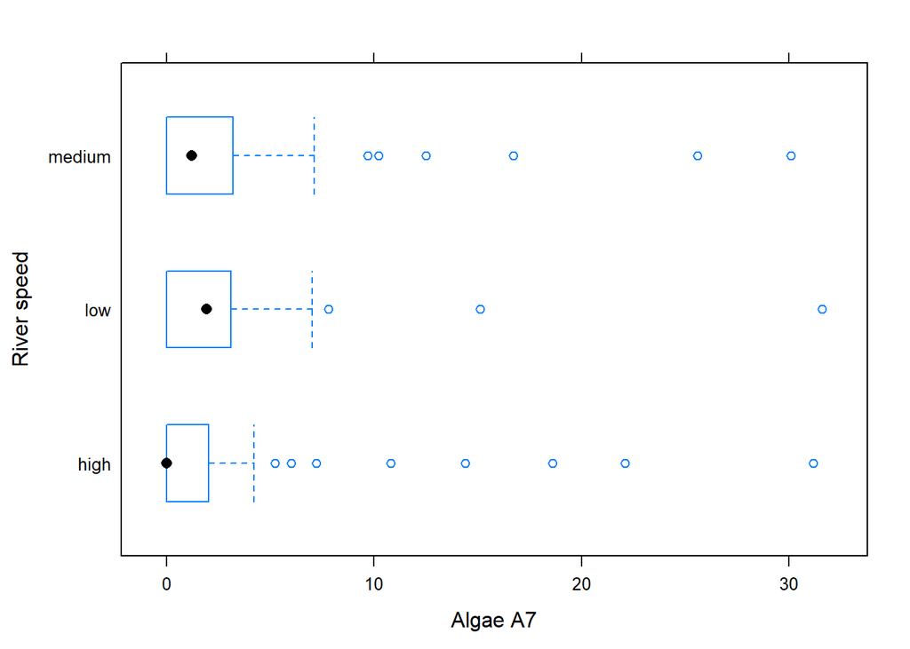

```r
bwplot(speed~a7,data=algaeDataset,xlab = "Algae A7",ylab = "River speed")
```

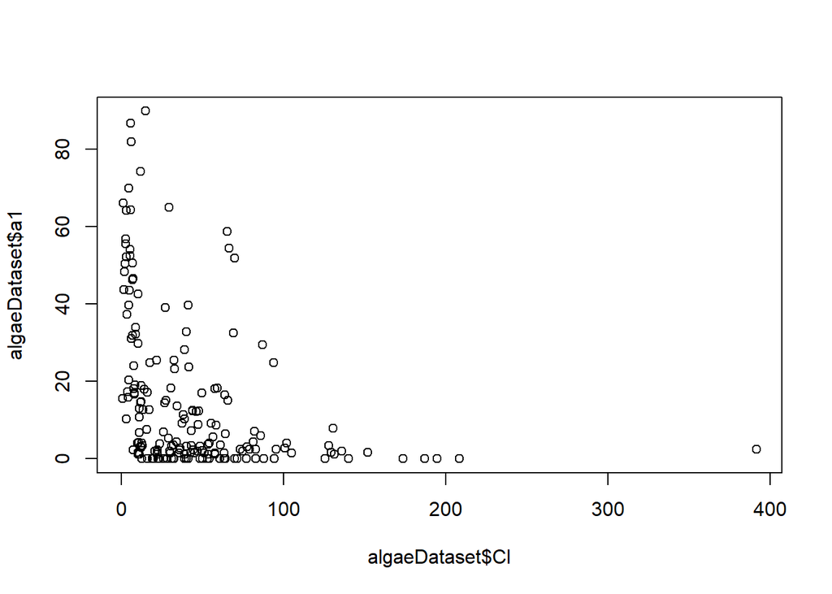

```r
plot(algaeDataset$a1 ~ algaeDataset$Cl)
```

# Multivariate Normal distribution check:

Here we have calculated covriance and column Means for the normal distribution check

```r
colnames(algaeDataset)
```

```
##  [1] "season" "size"   "speed"  "mxPH"   "mnO2"   "Cl"     "NO3"
##  [8] "NH4"    "oPO4"   "PO4"    "Chla"   "a1"     "a2"     "a3"
## [15] "a4"     "a5"     "a6"     "a7"
```

```r
x <- dist(scale(algaeDataset[, c("mxPH", "mnO2", "Cl","NO3","NH4","oPO4","PO4","Chla")],
center = FALSE))
as.dist(round(as.matrix(x), 2)[1:12, 1:12])
```

```
##       1    2    3    4    5    6    7    8    9   10   11
## 2  3.99
## 3  1.47 3.32
## 4  2.25 3.75 1.36
## 5  1.89 4.26 1.29 1.73
## 6  1.45 4.68 1.51 2.04 0.98
## 7  2.18 3.81 1.23 0.63 1.78 1.90
## 8  1.91 4.09 0.99 0.95 1.09 1.27 0.76
## 9  2.41 4.15 1.62 1.01 2.04 2.25 1.13 1.25
## 10 2.54 4.30 1.55 1.33 1.98 2.13 1.10 1.11 0.78
## 11 2.59 4.47 1.67 1.42 2.00 2.11 1.18 1.14 0.86 0.19
## 12 2.61 4.50 1.67 1.49 2.01 2.09 1.19 1.14 1.01 0.28 0.17
```

```r
x <- algaeDataset[, c("mxPH", "mnO2", "Cl","NO3","NH4","oPO4","PO4","Chla")]
cm <- colMeans(x)
S <- cov(x)
d <- apply(x, MARGIN = 1, function(x)t(x - cm) %*% solve(S) %*% (x - cm))
d
```

[output not shown]

```r
S
```

```
##              mxPH         mnO2         Cl          NO3          NH4
## mxPH    0.2225065   -0.1166057    3.26578   -0.3146066    -147.8650
## mnO2   -0.1166057    5.7944078  -29.82509    1.0997298    -382.7583
## Cl      3.2657796  -29.8250876 2215.30207   38.4726809    6309.3683
## NO3    -0.3146066    1.0997298   38.47268   15.0133862    5704.5208
## NH4  -147.8649973 -382.7582810 6309.36826 5704.5208456 4127337.0433
## oPO4    3.9421181  -87.7889395 1653.33413   47.7364490   41267.4404
## PO4     6.1710802 -144.1914158 2705.30776   78.5551787   52300.3410
## Chla    4.1277801   -6.4007720  136.35243   11.4240425    3754.8089
##              oPO4         PO4        Chla
## mxPH     3.942118     6.17108    4.127780
## mnO2   -87.788939  -144.19142   -6.400772
## Cl    1653.334129  2705.30776  136.352430
## NO3     47.736449    78.55518   11.424043
## NH4  41267.440358 52300.34101 3754.808912
## oPO4  8578.739540 10905.44454  200.672650
## PO4  10905.444542 16668.91384  650.137379
## Chla   200.672650   650.13738  410.655232
```

```r
cm ##from the column means we can say that mxPH,mnO2,NO3 and Chla are related because the column means are close enough
```

```
##       mxPH       mnO2         Cl        NO3        NH4       oPO4
##   8.078288   9.018587  44.880886   3.384071 537.671598  78.269446
##        PO4       Chla
## 146.577647  13.882799
```

## Now let us draw the normal Q-Q plot for all the chemicals observed in the river

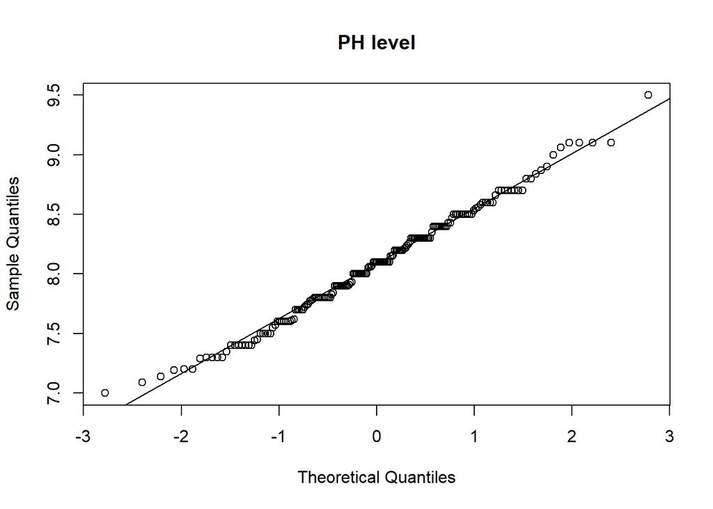

```r
{qqnorm(algaeDataset[,"mxPH"], main = "PH level")
  qqline(algaeDataset[,"mxPH"])}
```

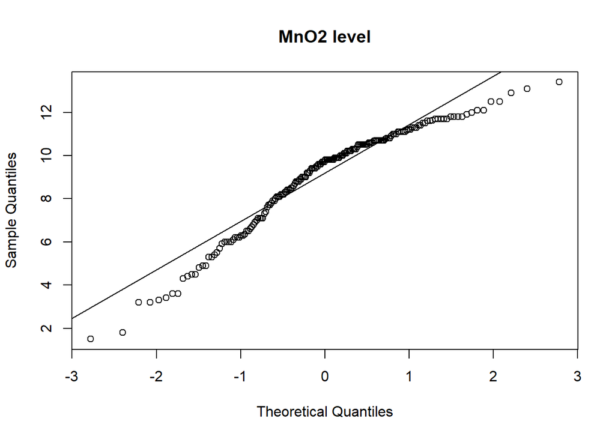

```r
{qqnorm(algaeDataset[,"mnO2"], main = "MnO2 level")
  qqline(algaeDataset[,"mnO2"])}
```

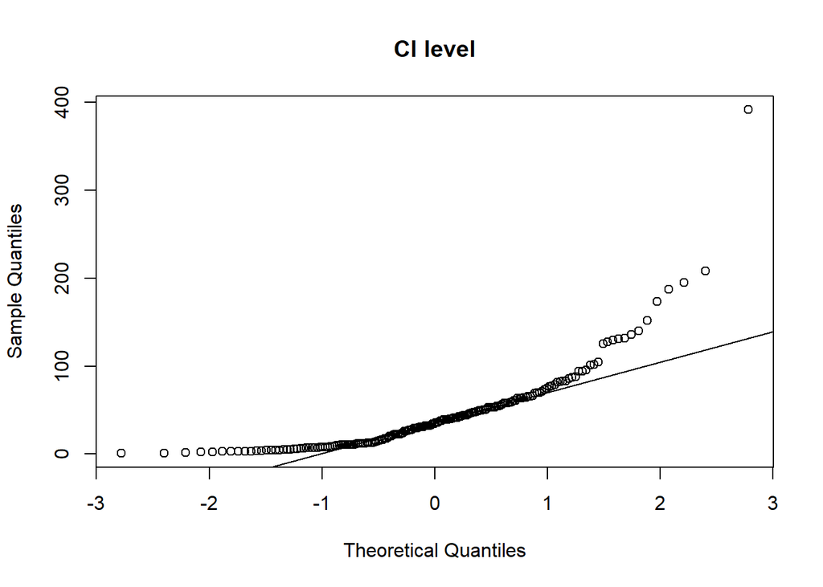

```r
{qqnorm(algaeDataset[,"Cl"], main = "Cl level")
  qqline(algaeDataset[,"Cl"])}
```

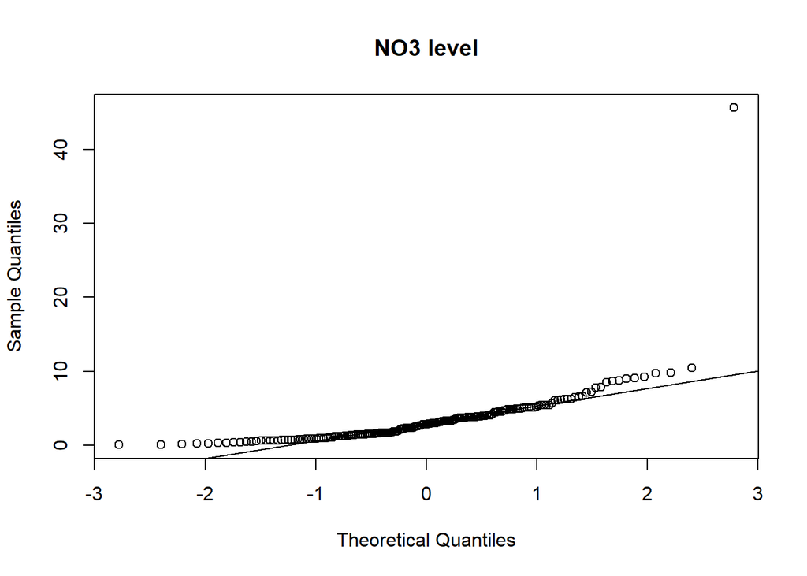

```r
{qqnorm(algaeDataset[,"NO3"], main = "NO3 level")
  qqline(algaeDataset[,"NO3"])}
```

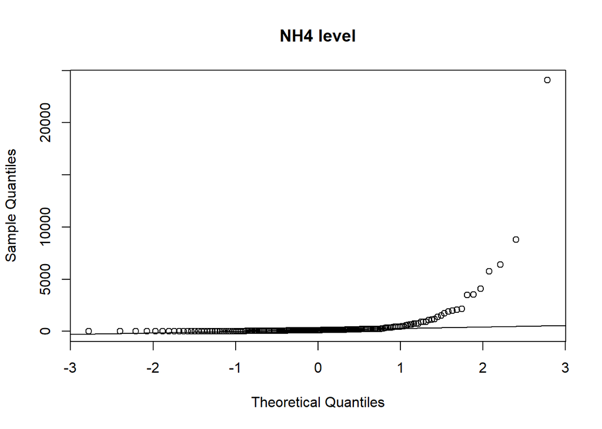

```r
{qqnorm(algaeDataset[,"NH4"], main = "NH4 level")
  qqline(algaeDataset[,"NH4"])}
```

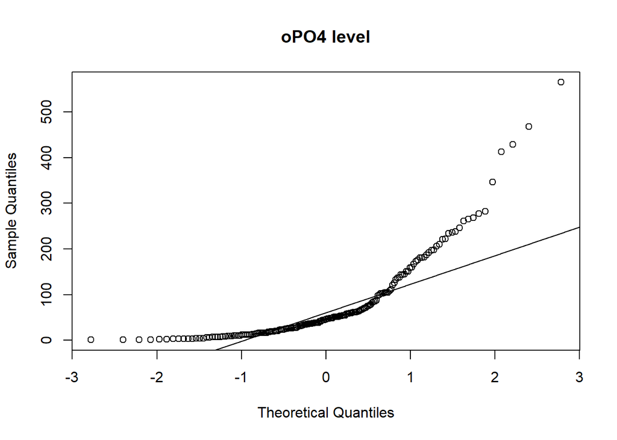

```r
{qqnorm(algaeDataset[,"oPO4"], main = "oPO4 level")
  qqline(algaeDataset[,"oPO4"])}
```

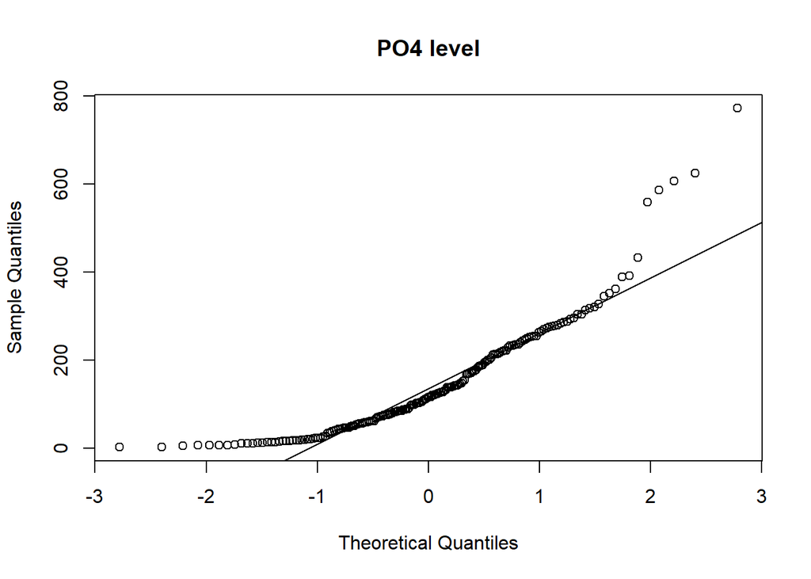

```r
{qqnorm(algaeDataset[,"PO4"], main = "PO4 level")
  qqline(algaeDataset[,"PO4"])}
```

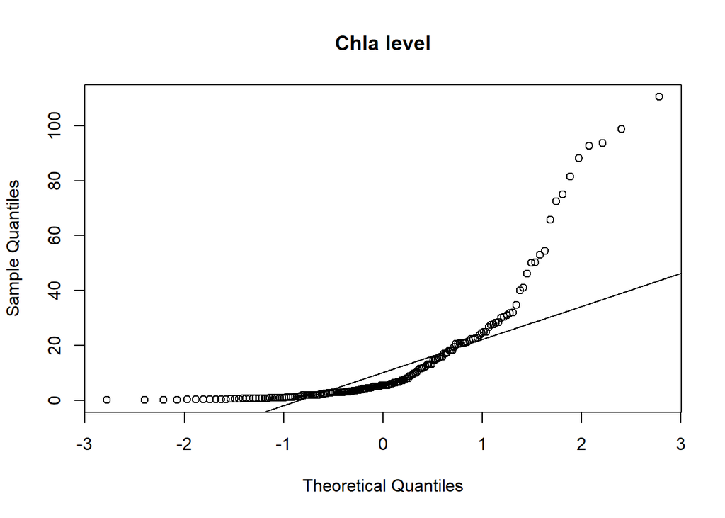

```r
{qqnorm(algaeDataset[,"Chla"], main = "Chla level")
  qqline(algaeDataset[,"Chla"])}
```

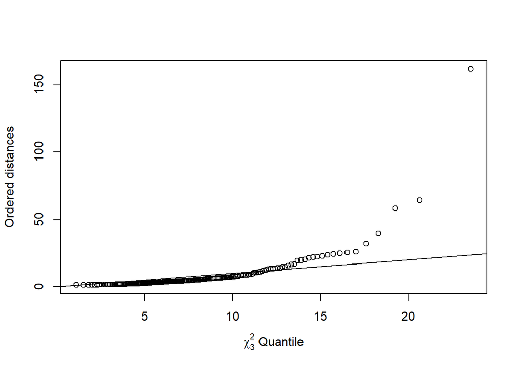

```r
{plot(qchisq((1:nrow(x) - 1/2) / nrow(x), df = 8), sort(d),
     xlab = expression(paste(chi[3]^2, " Quantile")),
     ylab = "Ordered distances")
abline(a = 0, b = 1)} ##symmetric distribution with flat tail on the right
```

# t-test statics are applied on based of the season on 7 different types of algae

Now we will perform t-test statistics for the season and the frequencies of the algae

```r
with(data=algaeDataset,t.test(a1[season=="winter"],a1[season=="spring"],var.equal=TRUE)) ## with this we say that yes there is a lot of algaes 1 blossmings during winter and spring
```

```
##
##  Two Sample t-test
##
## data:  a1[season == "winter"] and a1[season == "spring"]
## t = 0.97289, df = 103, p-value = 0.3329
## alternative hypothesis: true difference in means is not equal to 0
## 95 percent confidence interval:
##  -4.139611 12.111760
## sample estimates:
## mean of x mean of y
##  16.66316  12.67708
```

```r
with(data=algaeDataset,t.test(a1[season=="summer"],a1[season=="autumn"],var.equal=TRUE)) ## with this we say that yes there is a lot of algaes 1 blossmings during summer and autumn too
```

```
##
##  Two Sample t-test
##
## data:  a1[season == "summer"] and a1[season == "autumn"]
## t = -0.30938, df = 77, p-value = 0.7579
## alternative hypothesis: true difference in means is not equal to 0
## 95 percent confidence interval:
##  -10.255095   7.496956
## sample estimates:
## mean of x mean of y
##  15.32093  16.70000
```

```r
with(data=algaeDataset,t.test(a2[season=="winter"],a2[season=="spring"],var.equal=TRUE)) ##alage 2 also we can see the same amount of blossoms
```

```
##
##  Two Sample t-test
##
## data:  a2[season == "winter"] and a2[season == "spring"]
## t = 0.1761, df = 103, p-value = 0.8606
## alternative hypothesis: true difference in means is not equal to 0
## 95 percent confidence interval:
##  -3.645874  4.356401
## sample estimates:
## mean of x mean of y
##  7.538596  7.183333
```

```r
with(data=algaeDataset,t.test(a3[season=="winter"],a3[season=="spring"],var.equal=TRUE)) ## alage 3 also we can see the same amount of blossoms
```

```
##
##  Two Sample t-test
##
## data:  a3[season == "winter"] and a3[season == "spring"]
## t = -1.5426, df = 103, p-value = 0.126
## alternative hypothesis: true difference in means is not equal to 0
## 95 percent confidence interval:
##  -5.8004043  0.7249657
## sample estimates:
## mean of x mean of y
##  5.078947  7.616667
```

```r
with(data=algaeDataset,t.test(a4[season=="winter"],a4[season=="spring"],var.equal=TRUE)) ## alage 4 also we can see the same amount of blossoms
```

```
##
##  Two Sample t-test
##
## data:  a4[season == "winter"] and a4[season == "spring"]
## t = -0.88398, df = 103, p-value = 0.3788
## alternative hypothesis: true difference in means is not equal to 0
## 95 percent confidence interval:
##  -2.740677  1.050764
## sample estimates:
## mean of x mean of y
##  1.917544  2.762500
```

```r
with(data=algaeDataset,t.test(a5[season=="winter"],a5[season=="spring"],var.equal=TRUE)) ## alage 5 also we can see the same amount of blossoms
```

```
##
##  Two Sample t-test
##
## data:  a5[season == "winter"] and a5[season == "spring"]
## t = 0.82943, df = 103, p-value = 0.4088
## alternative hypothesis: true difference in means is not equal to 0
## 95 percent confidence interval:
##  -1.371902  3.344270
## sample estimates:
## mean of x mean of y
##  4.640351  3.654167
```

```r
with(data=algaeDataset,t.test(a6[season=="winter"],a6[season=="spring"],var.equal=TRUE)) ## alage 6 also we can see the same amount of blossoms
```

```
##
##  Two Sample t-test
##
## data:  a6[season == "winter"] and a6[season == "spring"]
## t = 1.7685, df = 103, p-value = 0.07994
## alternative hypothesis: true difference in means is not equal to 0
## 95 percent confidence interval:
##  -0.3745924  6.5443292
## sample estimates:
## mean of x mean of y
##  5.447368  2.362500
```

```r
with(data=algaeDataset,t.test(a7[season=="winter"],a7[season=="spring"],var.equal=TRUE)) ## alage 7 also we can see the same amount of blossoms
```

```
##
##  Two Sample t-test
##
## data:  a7[season == "winter"] and a7[season == "spring"]
## t = -0.29231, df = 103, p-value = 0.7706
## alternative hypothesis: true difference in means is not equal to 0
## 95 percent confidence interval:
##  -2.402050  1.784945
## sample estimates:
## mean of x mean of y
##  2.578947  2.887500
```

# Hotelling T2 test:

```r
#install.packages('Hotelling')
library(Hotelling)
t2testalgae <- hotelling.test(mxPH + mnO2 + Cl + NO3 +NH4 + oPO4 + PO4 + Chla ~ a1, data=algaeDataset)
cat("T2 statistic =",t2testalgae$stat[[1]],"\n")
```

```
## T2 statistic = 5.56422
```

```r
print(t2testalgae)
```

```
## Test stat:  0.56029
## Numerator df:  8
## Denominator df:  29
## P-value:  0.8011
```

```r
t2testalgae2 <- hotelling.test(mxPH + mnO2 + Cl + NO3 +NH4 + oPO4 + PO4 + Chla ~ a2, data=algaeDataset)
cat("T2 statistic =",t2testalgae2$stat[[1]],"\n")
```

```
## T2 statistic = 7.376566
```

```r
print(t2testalgae2)
```

```
## Test stat:  0.82277
## Numerator df:  8
## Denominator df:  58
## P-value:  0.5859
```

```r
t2testalgae3 <- hotelling.test(mxPH + mnO2 + Cl + NO3 +NH4 + oPO4 + PO4 + Chla ~ a3, data=algaeDataset)
cat("T2 statistic =",t2testalgae3$stat[[1]],"\n")
```

```
## T2 statistic = 3.961561
```

```r
print(t2testalgae3)
```

```
## Test stat:  0.44568
## Numerator df:  8
## Denominator df:  63
## P-value:  0.8888
```

```r
t2testalgae4 <- hotelling.test(mxPH + mnO2 + Cl + NO3 +NH4 + oPO4 + PO4 + Chla ~ a4, data=algaeDataset)
cat("T2 statistic =",t2testalgae4$stat[[1]],"\n")
```

```
## T2 statistic = 12.07326
```

```r
print(t2testalgae4)
```

```
## Test stat:  1.4066
## Numerator df:  8
## Denominator df:  96
## P-value:  0.2036
```

```r
t2testalgae5 <- hotelling.test(mxPH + mnO2 + Cl + NO3 +NH4 + oPO4 + PO4 + Chla ~ a5, data=algaeDataset)
cat("T2 statistic =",t2testalgae5$stat[[1]],"\n")
```

```
## T2 statistic = 18.55548
```

```r
print(t2testalgae5)
```

```
## Test stat:  2.0697
## Numerator df:  8
## Denominator df:  58
## P-value:  0.0537
```

```r
t2testalgae6 <- hotelling.test(mxPH + mnO2 + Cl + NO3 +NH4 + oPO4 + PO4 + Chla ~ a6, data=algaeDataset)
cat("T2 statistic =",t2testalgae6$stat[[1]],"\n")
```

```
## T2 statistic = NA
```

```r
print(t2testalgae6)
```

```
## Test stat:  NA
## Numerator df:  8
## Denominator df:  86
## P-value:  NA
```

```r
t2testalgae7 <- hotelling.test(mxPH + mnO2 + Cl + NO3 +NH4 + oPO4 + PO4 + Chla ~ a7, data=algaeDataset)
cat("T2 statistic =",t2testalgae7$stat[[1]],"\n")
```

```
## T2 statistic = 15.27807
```

```r
print(t2testalgae7)
```

```
## Test stat:  1.7629
## Numerator df:  8
## Denominator df:  84
## P-value:  0.09601
```

# Principal Component Analysis:

```r
dim(algaeDataset)
```

```
## [1] 184  18
```

```r
numericAlgaeData <- algaeDataset[,-c(1,2,3,12,13,14,15,16,17,18)]
cor(numericAlgaeData)
```

```
##             mxPH        mnO2          Cl        NO3         NH4
## mxPH  1.00000000 -0.10269374  0.14709539 -0.1721302 -0.15429757
## mnO2 -0.10269374  1.00000000 -0.26324536  0.1179077 -0.07826816
## Cl    0.14709539 -0.26324536  1.00000000  0.2109583  0.06598336
## NO3  -0.17213024  0.11790769  0.21095831  1.0000000  0.72467766
## NH4  -0.15429757 -0.07826816  0.06598336  0.7246777  1.00000000
## oPO4  0.09022909 -0.39375269  0.37925596  0.1330145  0.21931121
## PO4   0.10132957 -0.46396073  0.44519118  0.1570297  0.19939575
## Chla  0.43182377 -0.13121671  0.14295776  0.1454929  0.09120406
##             oPO4        PO4        Chla
## mxPH  0.09022909  0.1013296  0.43182377
## mnO2 -0.39375269 -0.4639607 -0.13121671
## Cl    0.37925596  0.4451912  0.14295776
## NO3   0.13301452  0.1570297  0.14549290
## NH4   0.21931121  0.1993958  0.09120406
## oPO4  1.00000000  0.9119646  0.10691478
## PO4   0.91196460  1.0000000  0.24849223
## Chla  0.10691478  0.2484922  1.00000000
```

```r
algae_pca <- prcomp(numericAlgaeData,scale = TRUE)
algae_pca
```

```
## Standard deviations (1, .., p=8):
## [1] 1.6534534 1.3228050 1.1314561 0.8800021 0.8182890 0.7177949 0.4570020
## [8] 0.2607780
##
## Rotation (n x k) = (8 x 8):
##             PC1         PC2          PC3         PC4          PC5
## mxPH  0.1229044 -0.41654322  0.561511592  0.04183663 -0.077012393
## mnO2 -0.3406130  0.24345520  0.224488272  0.45242066 -0.717115848
## Cl    0.3710606 -0.06688890 -0.004180915  0.80702475  0.381375926
## NO3   0.2234969  0.61831159  0.247678574  0.12982214  0.044840756
## NH4   0.2521532  0.58568950  0.147954838 -0.27347425  0.123589856
## oPO4  0.5157449 -0.07397518 -0.261019584 -0.05962805 -0.455432104
## PO4   0.5469393 -0.10037673 -0.187249761 -0.05833390 -0.331087209
## Chla  0.2291809 -0.14784435  0.669225868 -0.20898804 -0.006638359
##              PC6         PC7         PC8
## mxPH  0.68712332 -0.11191985  0.06119847
## mnO2 -0.05369360  0.21785668  0.07094528
## Cl   -0.06828080  0.23437668 -0.03861628
## NO3   0.02110287 -0.69577863 -0.05456656
## NH4   0.31297699  0.61468449  0.07511114
## oPO4  0.09139452  0.02136500 -0.66379242
## PO4  -0.11552993 -0.07266973  0.72392668
## Chla -0.63262645  0.13190038 -0.12814403
```

```r
summary(algae_pca)
```

```
## Importance of components:
##                           PC1    PC2    PC3    PC4    PC5    PC6     PC7
## Standard deviation     1.6535 1.3228 1.1315 0.8800 0.8183 0.7178 0.45700
## Proportion of Variance 0.3417 0.2187 0.1600 0.0968 0.0837 0.0644 0.02611
## Cumulative Proportion  0.3417 0.5605 0.7205 0.8173 0.9010 0.9654 0.99150
##                           PC8
## Standard deviation     0.2608
## Proportion of Variance 0.0085
## Cumulative Proportion  1.0000
```

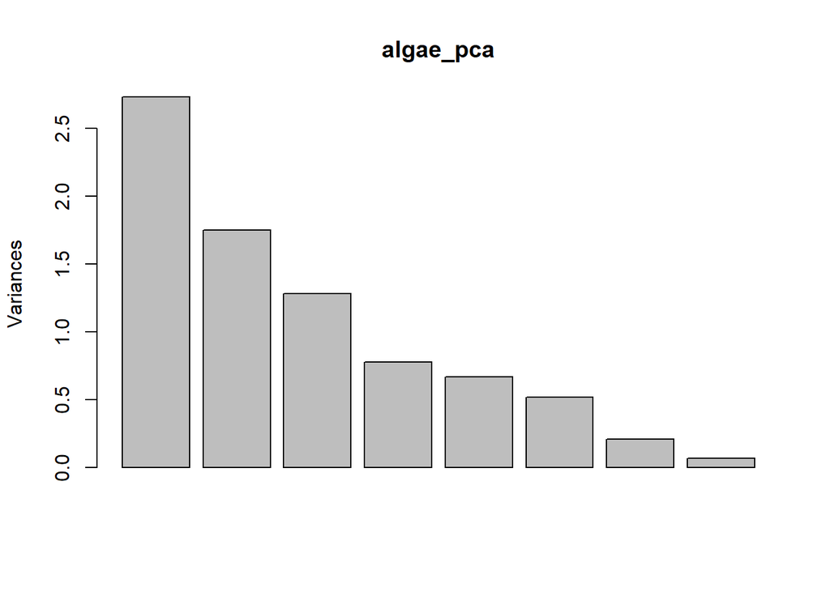

```r
plot(algae_pca)
```

```r
algaeDataset$a1Cat[algaeDataset$a1<=4.85] = "Less"
algaeDataset$a1Cat[algaeDataset$a1>4.85] = "More"
algaeDataset$a2Cat[algaeDataset$a2<=3.6] = "Less"
algaeDataset$a2Cat[algaeDataset$a2>3.6] = "More"
algaeDataset$a3Cat[algaeDataset$a3<=1.70] = "Less"
algaeDataset$a3Cat[algaeDataset$a3>1.70] = "More"
algaeDataset$a4Cat[algaeDataset$a4<=1.846] = "Less"
algaeDataset$a4Cat[algaeDataset$a4>1.846] = "More"
algaeDataset$a5Cat[algaeDataset$a5<=2.650] = "Less"
algaeDataset$a5Cat[algaeDataset$a5>2.650] = "More"
algaeDataset$a6Cat[algaeDataset$a6<=6.447] = "Less"
algaeDataset$a6Cat[algaeDataset$a6>6.447] = "More"
algaeDataset$a7Cat[algaeDataset$a7<=1.00] = "Less"
algaeDataset$a7Cat[algaeDataset$a7>1.00] = "More"
```

Let us find out eigen values:

```r
eigen_algaes <- algae_pca$sdev^2
eigen_algaes
```

```
## [1] 2.73390819 1.74981296 1.28019290 0.77440364 0.66959688 0.51522950
## [7] 0.20885079 0.06800514
```

```r
names(eigen_algaes) <- paste("PC",1:8,sep="")
eigen_algaes
```

```
##        PC1        PC2        PC3        PC4        PC5        PC6
## 2.73390819 1.74981296 1.28019290 0.77440364 0.66959688 0.51522950
##        PC7        PC8
## 0.20885079 0.06800514
```

```r
sumlambdas_algaes <- sum(eigen_algaes)
sumlambdas_algaes
```

```
## [1] 8
```

```r
propvar_algaes <- eigen_algaes/sumlambdas_algaes
propvar_algaes
```

```
##         PC1         PC2         PC3         PC4         PC5         PC6
## 0.341738523 0.218726620 0.160024113 0.096800454 0.083699610 0.064403688
##         PC7         PC8
## 0.026106349 0.008500642
```

```r
cumvar_algaes <- cumsum(propvar_algaes)
cumvar_algaes
```

```
##       PC1       PC2       PC3       PC4       PC5       PC6       PC7
## 0.3417385 0.5604651 0.7204893 0.8172897 0.9009893 0.9653930 0.9914994
##       PC8
## 1.0000000
```

```r
matlambdas_algaes <- rbind(eigen_algaes,propvar_algaes,cumvar_algaes)
matlambdas_algaes
```

```
##                      PC1       PC2       PC3        PC4        PC5
## eigen_algaes   2.7339082 1.7498130 1.2801929 0.77440364 0.66959688
## propvar_algaes 0.3417385 0.2187266 0.1600241 0.09680045 0.08369961
## cumvar_algaes  0.3417385 0.5604651 0.7204893 0.81728971 0.90098932
##                       PC6        PC7         PC8
## eigen_algaes   0.51522950 0.20885079 0.068005139
## propvar_algaes 0.06440369 0.02610635 0.008500642
## cumvar_algaes  0.96539301 0.99149936 1.000000000
```

```r
rownames(matlambdas_algaes) <- c("Eigenvalues","Prop. variance","Cum. prop. variance")
round(matlambdas_algaes,4)
```

```
##                        PC1    PC2    PC3    PC4    PC5    PC6    PC7
## Eigenvalues         2.7339 1.7498 1.2802 0.7744 0.6696 0.5152 0.2089
## Prop. variance      0.3417 0.2187 0.1600 0.0968 0.0837 0.0644 0.0261
## Cum. prop. variance 0.3417 0.5605 0.7205 0.8173 0.9010 0.9654 0.9915
##                        PC8
## Eigenvalues         0.0680
## Prop. variance      0.0085
## Cum. prop. variance 1.0000
```

```r
attach(algaeDataset)
algae_pca$rotation
```

```
##             PC1         PC2          PC3         PC4          PC5
## mxPH  0.1229044 -0.41654322  0.561511592  0.04183663 -0.077012393
## mnO2 -0.3406130  0.24345520  0.224488272  0.45242066 -0.717115848
## Cl    0.3710606 -0.06688890 -0.004180915  0.80702475  0.381375926
## NO3   0.2234969  0.61831159  0.247678574  0.12982214  0.044840756
## NH4   0.2521532  0.58568950  0.147954838 -0.27347425  0.123589856
## oPO4  0.5157449 -0.07397518 -0.261019584 -0.05962805 -0.455432104
## PO4   0.5469393 -0.10037673 -0.187249761 -0.05833390 -0.331087209
## Chla  0.2291809 -0.14784435  0.669225868 -0.20898804 -0.006638359
##              PC6         PC7         PC8
## mxPH  0.68712332 -0.11191985  0.06119847
## mnO2 -0.05369360  0.21785668  0.07094528
## Cl   -0.06828080  0.23437668 -0.03861628
## NO3   0.02110287 -0.69577863 -0.05456656
## NH4   0.31297699  0.61468449  0.07511114
## oPO4  0.09139452  0.02136500 -0.66379242
## PO4  -0.11552993 -0.07266973  0.72392668
## Chla -0.63262645  0.13190038 -0.12814403
```

```r
print(algae_pca)
```

```
## Standard deviations (1, .., p=8):
## [1] 1.6534534 1.3228050 1.1314561 0.8800021 0.8182890 0.7177949 0.4570020
## [8] 0.2607780
##
## Rotation (n x k) = (8 x 8):
##             PC1         PC2          PC3         PC4          PC5
## mxPH  0.1229044 -0.41654322  0.561511592  0.04183663 -0.077012393
## mnO2 -0.3406130  0.24345520  0.224488272  0.45242066 -0.717115848
## Cl    0.3710606 -0.06688890 -0.004180915  0.80702475  0.381375926
## NO3   0.2234969  0.61831159  0.247678574  0.12982214  0.044840756
## NH4   0.2521532  0.58568950  0.147954838 -0.27347425  0.123589856
## oPO4  0.5157449 -0.07397518 -0.261019584 -0.05962805 -0.455432104
## PO4   0.5469393 -0.10037673 -0.187249761 -0.05833390 -0.331087209
## Chla  0.2291809 -0.14784435  0.669225868 -0.20898804 -0.006638359
##              PC6         PC7         PC8
## mxPH  0.68712332 -0.11191985  0.06119847
## mnO2 -0.05369360  0.21785668  0.07094528
## Cl   -0.06828080  0.23437668 -0.03861628
## NO3   0.02110287 -0.69577863 -0.05456656
## NH4   0.31297699  0.61468449  0.07511114
## oPO4  0.09139452  0.02136500 -0.66379242
## PO4  -0.11552993 -0.07266973  0.72392668
## Chla -0.63262645  0.13190038 -0.12814403
```

```r
algaetyp_pca <- cbind(data.frame(a1Cat),algae_pca$x)
algaetyp_pca
```

```
##     a1Cat          PC1         PC2          PC3         PC4          PC5
## 1    Less  0.820687351  0.28952661  1.247077898  0.10280148 -0.258871961
## 2    Less  3.730027226 -1.25263632 -1.919915169 -0.27643930 -2.447314074
## 3    Less  0.173728419  0.40219049  0.223270034  0.39055864 -1.078906577
## 4    Less  0.464201113 -0.65403533 -0.860002099 -0.07044543  1.590370250
## 5    More  0.090824457  1.11267251  0.418767667  0.52084488  0.381573327
## 6    More -0.594295147  1.14812498  1.729132129  1.28066393 -0.492580725
## 7    Less -0.461845357 -0.27379594 -0.201312021  0.86610489 -0.034500048
## 8    More -0.626870183  0.45685288  0.155396725  0.76133867 -0.008336383
## 9    More -0.070006256 -1.45557256 -0.020718879 -1.27202952  1.734070270
## 10   More -1.490732163  0.01488890 -0.400514057 -0.26213845 -0.081104340
## 11   More -1.773498154  0.30642031 -0.558065117 -0.20267156  0.007206828
## 12   More -2.063592422  0.69122272 -0.710360856  0.07556950 -0.377940602
## 13   More -1.284076861 -0.12195696  0.749976035 -0.78668971  0.152078804
## 14   More -2.022716140  0.44405111 -0.400251269  0.07418711 -0.489111165
```

[output cut: 355 more lines]

```r
algaetyp_pca2 <- cbind(data.frame(a2Cat),algae_pca$x)
algaetyp_pca3 <- cbind(data.frame(a3Cat),algae_pca$x)
algaetyp_pca4 <- cbind(data.frame(a4Cat),algae_pca$x)
algaetyp_pca5 <- cbind(data.frame(a5Cat),algae_pca$x)
algaetyp_pca6 <- cbind(data.frame(a6Cat),algae_pca$x)
algaetyp_pca7 <- cbind(data.frame(a7Cat),algae_pca$x)
```

T-test for PCA:

```r
#install.packages('car')
library(car)
t.test(PC1~algaeDataset$a1Cat,data=algaetyp_pca)
```

```
##
##  Welch Two Sample t-test
##
## data:  PC1 by algaeDataset$a1Cat
## t = 7.8119, df = 161.94, p-value = 6.696e-13
## alternative hypothesis: true difference in means is not equal to 0
## 95 percent confidence interval:
##  1.234850 2.070354
## sample estimates:
## mean in group Less mean in group More
##           0.826301          -0.826301
```

```r
t.test(PC2~algaeDataset$a1Cat,data=algaetyp_pca)
```

```
##
##  Welch Two Sample t-test
##
## data:  PC2 by algaeDataset$a1Cat
## t = -0.6213, df = 119.51, p-value = 0.5356
## alternative hypothesis: true difference in means is not equal to 0
## 95 percent confidence interval:
##  -0.5082051  0.2654453
## sample estimates:
## mean in group Less mean in group More
##        -0.06068993         0.06068993
```

```r
t.test(PC3~algaeDataset$a1Cat,data=algaetyp_pca)
```

```
##
##  Welch Two Sample t-test
##
## data:  PC3 by algaeDataset$a1Cat
## t = 0.98186, df = 150.27, p-value = 0.3277
## alternative hypothesis: true difference in means is not equal to 0
## 95 percent confidence interval:
##  -0.1658423  0.4934700
## sample estimates:
## mean in group Less mean in group More
##         0.08190691        -0.08190691
```

```r
t.test(PC4~algaeDataset$a1Cat,data=algaetyp_pca)
```

```
##
##  Welch Two Sample t-test
##
## data:  PC4 by algaeDataset$a1Cat
## t = 1.7282, df = 137.97, p-value = 0.0862
## alternative hypothesis: true difference in means is not equal to 0
## 95 percent confidence interval:
##  -0.03215227  0.47819324
## sample estimates:
## mean in group Less mean in group More
##          0.1115102         -0.1115102
```

```r
t.test(PC5~algaeDataset$a1Cat,data=algaetyp_pca)
```

```
##
##  Welch Two Sample t-test
##
## data:  PC5 by algaeDataset$a1Cat
## t = -0.74733, df = 147.55, p-value = 0.4561
## alternative hypothesis: true difference in means is not equal to 0
## 95 percent confidence interval:
##  -0.3289875  0.1484396
## sample estimates:
## mean in group Less mean in group More
##        -0.04513696         0.04513696
```

```r
t.test(PC6~algaeDataset$a1Cat,data=algaetyp_pca)
```

```
##
##  Welch Two Sample t-test
##
## data:  PC6 by algaeDataset$a1Cat
## t = -0.045498, df = 167.61, p-value = 0.9638
## alternative hypothesis: true difference in means is not equal to 0
## 95 percent confidence interval:
##  -0.2143380  0.2046813
## sample estimates:
## mean in group Less mean in group More
##       -0.002414193        0.002414193
```

```r
t.test(PC7~algaeDataset$a1Cat,data=algaetyp_pca)
```

```
##
##  Welch Two Sample t-test
##
## data:  PC7 by algaeDataset$a1Cat
## t = -1.9193, df = 174.44, p-value = 0.05658
## alternative hypothesis: true difference in means is not equal to 0
## 95 percent confidence interval:
##  -0.260408434  0.003637506
## sample estimates:
## mean in group Less mean in group More
##        -0.06419273         0.06419273
```

F-test for PCA:

```r
var.test(PC1~algaeDataset$a1Cat,data=algaetyp_pca)
```

```
##
##  F test to compare two variances
##
## data:  PC1 by algaeDataset$a1Cat
## F = 2.0862, num df = 91, denom df = 91, p-value = 0.000541
## alternative hypothesis: true ratio of variances is not equal to 1
## 95 percent confidence interval:
##  1.379658 3.154552
## sample estimates:
## ratio of variances
##           2.086193
```

```r
var.test(PC2~algaeDataset$a1Cat,data=algaetyp_pca)
```

```
##
##  F test to compare two variances
##
## data:  PC2 by algaeDataset$a1Cat
## F = 6.2232, num df = 91, denom df = 91, p-value = 2.22e-16
## alternative hypothesis: true ratio of variances is not equal to 1
## 95 percent confidence interval:
##  4.115546 9.410091
## sample estimates:
## ratio of variances
##           6.223156
```

```r
var.test(PC3~algaeDataset$a1Cat,data=algaetyp_pca)
```

```
##
##  F test to compare two variances
##
## data:  PC3 by algaeDataset$a1Cat
## F = 2.7002, num df = 91, denom df = 91, p-value = 3.605e-06
## alternative hypothesis: true ratio of variances is not equal to 1
## 95 percent confidence interval:
##  1.785688 4.082929
## sample estimates:
## ratio of variances
##           2.700155
```

```r
var.test(PC4~algaeDataset$a1Cat,data=algaetyp_pca)
```

```
##
##  F test to compare two variances
##
## data:  PC4 by algaeDataset$a1Cat
## F = 3.5964, num df = 91, denom df = 91, p-value = 3.678e-09
## alternative hypothesis: true ratio of variances is not equal to 1
## 95 percent confidence interval:
##  2.378376 5.438095
## sample estimates:
## ratio of variances
##           3.596364
```

```r
var.test(PC5~algaeDataset$a1Cat,data=algaetyp_pca)
```

```
##
##  F test to compare two variances
##
## data:  PC5 by algaeDataset$a1Cat
## F = 2.8699, num df = 91, denom df = 91, p-value = 9.306e-07
## alternative hypothesis: true ratio of variances is not equal to 1
## 95 percent confidence interval:
##  1.897970 4.339659
## sample estimates:
## ratio of variances
##           2.869937
```

```r
var.test(PC6~algaeDataset$a1Cat,data=algaetyp_pca)
```

```
##
##  F test to compare two variances
##
## data:  PC6 by algaeDataset$a1Cat
## F = 0.54678, num df = 91, denom df = 91, p-value = 0.004368
## alternative hypothesis: true ratio of variances is not equal to 1
## 95 percent confidence interval:
##  0.3616024 0.8267947
## sample estimates:
## ratio of variances
##          0.5467824
```

```r
var.test(PC7~algaeDataset$a1Cat,data=algaetyp_pca)
```

```
##
##  F test to compare two variances
##
## data:  PC7 by algaeDataset$a1Cat
## F = 1.5259, num df = 91, denom df = 91, p-value = 0.04521
## alternative hypothesis: true ratio of variances is not equal to 1
## 95 percent confidence interval:
##  1.009126 2.307341
## sample estimates:
## ratio of variances
##           1.525909
```

Levene’s test for PCA with algae1:

```r
(LTPC1_algae <- leveneTest(PC1~algaeDataset$a1Cat,data=algaetyp_pca))
```

```
## Levene's Test for Homogeneity of Variance (center = median)
##        Df F value   Pr(>F)
## group   1  7.4199 0.007079 **
##       182
## ---
## Signif. codes:  0 '***' 0.001 '**' 0.01 '*' 0.05 '.' 0.1 ' ' 1
```

```r
(LTPC2_algae <- leveneTest(PC2~algaeDataset$a1Cat,data=algaetyp_pca))
```

```
## Levene's Test for Homogeneity of Variance (center = median)
##        Df F value Pr(>F)
## group   1  2.4241 0.1212
##       182
```

```r
(LTPC3_algae <- leveneTest(PC3~algaeDataset$a1Cat,data=algaetyp_pca))
```

```
## Levene's Test for Homogeneity of Variance (center = median)
##        Df F value   Pr(>F)
## group   1  8.5103 0.003976 **
##       182
## ---
## Signif. codes:  0 '***' 0.001 '**' 0.01 '*' 0.05 '.' 0.1 ' ' 1
```

```r
(LTPC4_algae <- leveneTest(PC4~algaeDataset$a1Cat,data=algaetyp_pca))
```

```
## Levene's Test for Homogeneity of Variance (center = median)
##        Df F value   Pr(>F)
## group   1  10.753 0.001247 **
##       182
## ---
## Signif. codes:  0 '***' 0.001 '**' 0.01 '*' 0.05 '.' 0.1 ' ' 1
```

```r
(LTPC5_algae <- leveneTest(PC5~algaeDataset$a1Cat,data=algaetyp_pca))
```

```
## Levene's Test for Homogeneity of Variance (center = median)
##        Df F value   Pr(>F)
## group   1  21.654 6.27e-06 ***
##       182
## ---
## Signif. codes:  0 '***' 0.001 '**' 0.01 '*' 0.05 '.' 0.1 ' ' 1
```

```r
(LTPC6_algae <- leveneTest(PC6~algaeDataset$a1Cat,data=algaetyp_pca))
```

```
## Levene's Test for Homogeneity of Variance (center = median)
##        Df F value  Pr(>F)
## group   1  6.5081 0.01156 *
##       182
## ---
## Signif. codes:  0 '***' 0.001 '**' 0.01 '*' 0.05 '.' 0.1 ' ' 1
```

```r
(LTPC7_algae <- leveneTest(PC7~algaeDataset$a1Cat,data=algaetyp_pca))
```

```
## Levene's Test for Homogeneity of Variance (center = median)
##        Df F value Pr(>F)
## group   1  2.6048 0.1083
##       182
```

Levene’s test for PCA with algae2:

```r
(LTPC1_algae <- leveneTest(PC1~algaeDataset$a2Cat,data=algaetyp_pca2))
```

```
## Levene's Test for Homogeneity of Variance (center = median)
##        Df F value Pr(>F)
## group   1  0.3361 0.5628
##       182
```

```r
(LTPC2_algae <- leveneTest(PC2~algaeDataset$a2Cat,data=algaetyp_pca2))
```

```
## Levene's Test for Homogeneity of Variance (center = median)
##        Df F value Pr(>F)
## group   1  0.0341 0.8537
##       182
```

```r
(LTPC3_algae <- leveneTest(PC3~algaeDataset$a2Cat,data=algaetyp_pca2))
```

```
## Levene's Test for Homogeneity of Variance (center = median)
##        Df F value  Pr(>F)
## group   1  2.8616 0.09243 .
##       182
## ---
## Signif. codes:  0 '***' 0.001 '**' 0.01 '*' 0.05 '.' 0.1 ' ' 1
```

```r
(LTPC4_algae <- leveneTest(PC4~algaeDataset$a2Cat,data=algaetyp_pca2))
```

```
## Levene's Test for Homogeneity of Variance (center = median)
##        Df F value Pr(>F)
## group   1  0.0631  0.802
##       182
```

```r
(LTPC5_algae <- leveneTest(PC5~algaeDataset$a2Cat,data=algaetyp_pca2))
```

```
## Levene's Test for Homogeneity of Variance (center = median)
##        Df F value Pr(>F)
## group   1  0.5538 0.4577
##       182
```

```r
(LTPC6_algae <- leveneTest(PC6~algaeDataset$a2Cat,data=algaetyp_pca2))
```

```
## Levene's Test for Homogeneity of Variance (center = median)
##        Df F value Pr(>F)
## group   1  0.0305 0.8616
##       182
```

```r
(LTPC7_algae <- leveneTest(PC7~algaeDataset$a2Cat,data=algaetyp_pca2))
```

```
## Levene's Test for Homogeneity of Variance (center = median)
##        Df F value Pr(>F)
## group   1  0.5315 0.4669
##       182
```

Levene’s test for PCA with algae3:

```r
(LTPC1_algae <- leveneTest(PC1~algaeDataset$a3Cat,data=algaetyp_pca3))
```

```
## Levene's Test for Homogeneity of Variance (center = median)
##        Df F value Pr(>F)
## group   1  0.2599 0.6108
##       182
```

```r
(LTPC2_algae <- leveneTest(PC2~algaeDataset$a3Cat,data=algaetyp_pca3))
```

```
## Levene's Test for Homogeneity of Variance (center = median)
##        Df F value Pr(>F)
## group   1  0.4843 0.4874
##       182
```

```r
(LTPC3_algae <- leveneTest(PC3~algaeDataset$a3Cat,data=algaetyp_pca3))
```

```
## Levene's Test for Homogeneity of Variance (center = median)
##        Df F value Pr(>F)
## group   1  0.0728 0.7876
##       182
```

```r
(LTPC4_algae <- leveneTest(PC4~algaeDataset$a3Cat,data=algaetyp_pca3))
```

```
## Levene's Test for Homogeneity of Variance (center = median)
##        Df F value Pr(>F)
## group   1  1.9103 0.1686
##       182
```

```r
(LTPC5_algae <- leveneTest(PC5~algaeDataset$a3Cat,data=algaetyp_pca3))
```

```
## Levene's Test for Homogeneity of Variance (center = median)
##        Df F value Pr(>F)
## group   1  0.0484 0.8261
##       182
```

```r
(LTPC6_algae <- leveneTest(PC6~algaeDataset$a3Cat,data=algaetyp_pca3))
```

```
## Levene's Test for Homogeneity of Variance (center = median)
##        Df F value Pr(>F)
## group   1  0.5406 0.4631
##       182
```

```r
(LTPC7_algae <- leveneTest(PC7~algaeDataset$a3Cat,data=algaetyp_pca3))
```

```
## Levene's Test for Homogeneity of Variance (center = median)
##        Df F value Pr(>F)
## group   1  1.0675 0.3029
##       182
```

Levene’s test for PCA with algae4:

```r
(LTPC1_algae <- leveneTest(PC1~algaeDataset$a4Cat,data=algaetyp_pca4))
```

```
## Levene's Test for Homogeneity of Variance (center = median)
##        Df F value Pr(>F)
## group   1  1.7754 0.1844
##       182
```

```r
(LTPC2_algae <- leveneTest(PC2~algaeDataset$a4Cat,data=algaetyp_pca4))
```

```
## Levene's Test for Homogeneity of Variance (center = median)
##        Df F value Pr(>F)
## group   1  2.4405   0.12
##       182
```

```r
(LTPC3_algae <- leveneTest(PC3~algaeDataset$a4Cat,data=algaetyp_pca4))
```

```
## Levene's Test for Homogeneity of Variance (center = median)
##        Df F value Pr(>F)
## group   1  2.0726 0.1517
##       182
```

```r
(LTPC4_algae <- leveneTest(PC4~algaeDataset$a4Cat,data=algaetyp_pca4))
```

```
## Levene's Test for Homogeneity of Variance (center = median)
##        Df F value Pr(>F)
## group   1  0.7041 0.4025
##       182
```

```r
(LTPC5_algae <- leveneTest(PC5~algaeDataset$a4Cat,data=algaetyp_pca4))
```

```
## Levene's Test for Homogeneity of Variance (center = median)
##        Df F value  Pr(>F)
## group   1   2.739 0.09965 .
##       182
## ---
## Signif. codes:  0 '***' 0.001 '**' 0.01 '*' 0.05 '.' 0.1 ' ' 1
```

```r
(LTPC6_algae <- leveneTest(PC6~algaeDataset$a4Cat,data=algaetyp_pca4))
```

```
## Levene's Test for Homogeneity of Variance (center = median)
##        Df F value  Pr(>F)
## group   1  2.9668 0.08669 .
##       182
## ---
## Signif. codes:  0 '***' 0.001 '**' 0.01 '*' 0.05 '.' 0.1 ' ' 1
```

```r
(LTPC7_algae <- leveneTest(PC7~algaeDataset$a4Cat,data=algaetyp_pca4))
```

```
## Levene's Test for Homogeneity of Variance (center = median)
##        Df F value  Pr(>F)
## group   1  2.7424 0.09944 .
##       182
## ---
## Signif. codes:  0 '***' 0.001 '**' 0.01 '*' 0.05 '.' 0.1 ' ' 1
```

Levene’s test for PCA with algae5:

```r
(LTPC1_algae <- leveneTest(PC1~algaeDataset$a5Cat,data=algaetyp_pca5))
```

```
## Levene's Test for Homogeneity of Variance (center = median)
##        Df F value Pr(>F)
## group   1  2.5008 0.1155
##       182
```

```r
(LTPC2_algae <- leveneTest(PC2~algaeDataset$a5Cat,data=algaetyp_pca5))
```

```
## Levene's Test for Homogeneity of Variance (center = median)
##        Df F value Pr(>F)
## group   1  0.1026 0.7491
##       182
```

```r
(LTPC3_algae <- leveneTest(PC3~algaeDataset$a5Cat,data=algaetyp_pca5))
```

```
## Levene's Test for Homogeneity of Variance (center = median)
##        Df F value  Pr(>F)
## group   1  3.0766 0.08111 .
##       182
## ---
## Signif. codes:  0 '***' 0.001 '**' 0.01 '*' 0.05 '.' 0.1 ' ' 1
```

```r
(LTPC4_algae <- leveneTest(PC4~algaeDataset$a5Cat,data=algaetyp_pca5))
```

```
## Levene's Test for Homogeneity of Variance (center = median)
##        Df F value Pr(>F)
## group   1  0.4938 0.4832
##       182
```

```r
(LTPC5_algae <- leveneTest(PC5~algaeDataset$a5Cat,data=algaetyp_pca5))
```

```
## Levene's Test for Homogeneity of Variance (center = median)
##        Df F value Pr(>F)
## group   1   1.288 0.2579
##       182
```

```r
(LTPC6_algae <- leveneTest(PC6~algaeDataset$a5Cat,data=algaetyp_pca5))
```

```
## Levene's Test for Homogeneity of Variance (center = median)
##        Df F value  Pr(>F)
## group   1  5.5957 0.01906 *
##       182
## ---
## Signif. codes:  0 '***' 0.001 '**' 0.01 '*' 0.05 '.' 0.1 ' ' 1
```

```r
(LTPC7_algae <- leveneTest(PC7~algaeDataset$a5Cat,data=algaetyp_pca5))
```

```
## Levene's Test for Homogeneity of Variance (center = median)
##        Df F value Pr(>F)
## group   1  0.0044 0.9472
##       182
```

Levene’s test for PCA with algae6:

```r
(LTPC1_algae <- leveneTest(PC1~algaeDataset$a6Cat,data=algaetyp_pca6))
```

```
## Levene's Test for Homogeneity of Variance (center = median)
##        Df F value Pr(>F)
## group   1  1.9162  0.168
##       182
```

```r
(LTPC2_algae <- leveneTest(PC2~algaeDataset$a6Cat,data=algaetyp_pca6))
```

```
## Levene's Test for Homogeneity of Variance (center = median)
##        Df F value Pr(>F)
## group   1  2.4153 0.1219
##       182
```

```r
(LTPC3_algae <- leveneTest(PC3~algaeDataset$a6Cat,data=algaetyp_pca6))
```

```
## Levene's Test for Homogeneity of Variance (center = median)
##        Df F value Pr(>F)
## group   1  0.4671 0.4952
##       182
```

```r
(LTPC4_algae <- leveneTest(PC4~algaeDataset$a6Cat,data=algaetyp_pca6))
```

```
## Levene's Test for Homogeneity of Variance (center = median)
##        Df F value Pr(>F)
## group   1  0.2279 0.6337
##       182
```

```r
(LTPC5_algae <- leveneTest(PC5~algaeDataset$a6Cat,data=algaetyp_pca6))
```

```
## Levene's Test for Homogeneity of Variance (center = median)
##        Df F value Pr(>F)
## group   1  1.4475 0.2305
##       182
```

```r
(LTPC6_algae <- leveneTest(PC6~algaeDataset$a6Cat,data=algaetyp_pca6))
```

```
## Levene's Test for Homogeneity of Variance (center = median)
##        Df F value Pr(>F)
## group   1  0.4116 0.5219
##       182
```

```r
(LTPC7_algae <- leveneTest(PC7~algaeDataset$a6Cat,data=algaetyp_pca6))
```

```
## Levene's Test for Homogeneity of Variance (center = median)
##        Df F value Pr(>F)
## group   1  0.0039 0.9505
##       182
```

Levene’s test for PCA with algae7:

```r
(LTPC1_algae <- leveneTest(PC1~algaeDataset$a7Cat,data=algaetyp_pca7))
```

```
## Levene's Test for Homogeneity of Variance (center = median)
##        Df F value Pr(>F)
## group   1  1.6335 0.2029
##       182
```

```r
(LTPC2_algae <- leveneTest(PC2~algaeDataset$a7Cat,data=algaetyp_pca7))
```

```
## Levene's Test for Homogeneity of Variance (center = median)
##        Df F value Pr(>F)
## group   1  0.1209 0.7285
##       182
```

```r
(LTPC3_algae <- leveneTest(PC3~algaeDataset$a7Cat,data=algaetyp_pca7))
```

```
## Levene's Test for Homogeneity of Variance (center = median)
##        Df F value  Pr(>F)
## group   1  4.9291 0.02764 *
##       182
## ---
## Signif. codes:  0 '***' 0.001 '**' 0.01 '*' 0.05 '.' 0.1 ' ' 1
```

```r
(LTPC4_algae <- leveneTest(PC4~algaeDataset$a7Cat,data=algaetyp_pca7))
```

```
## Levene's Test for Homogeneity of Variance (center = median)
##        Df F value Pr(>F)
## group   1  0.0491 0.8248
##       182
```

```r
(LTPC5_algae <- leveneTest(PC5~algaeDataset$a7Cat,data=algaetyp_pca7))
```

```
## Levene's Test for Homogeneity of Variance (center = median)
##        Df F value Pr(>F)
## group   1  0.0564 0.8126
##       182
```

```r
(LTPC6_algae <- leveneTest(PC6~algaeDataset$a7Cat,data=algaetyp_pca7))
```

```
## Levene's Test for Homogeneity of Variance (center = median)
##        Df F value Pr(>F)
## group   1  1.0612 0.3043
##       182
```

```r
(LTPC7_algae <- leveneTest(PC7~algaeDataset$a7Cat,data=algaetyp_pca7))
```

```
## Levene's Test for Homogeneity of Variance (center = median)
##        Df F value Pr(>F)
## group   1    1.88  0.172
##       182
```

# Scree Diagram:

From the below Scree diagram we conclude that upto PC5 it is significant to consider

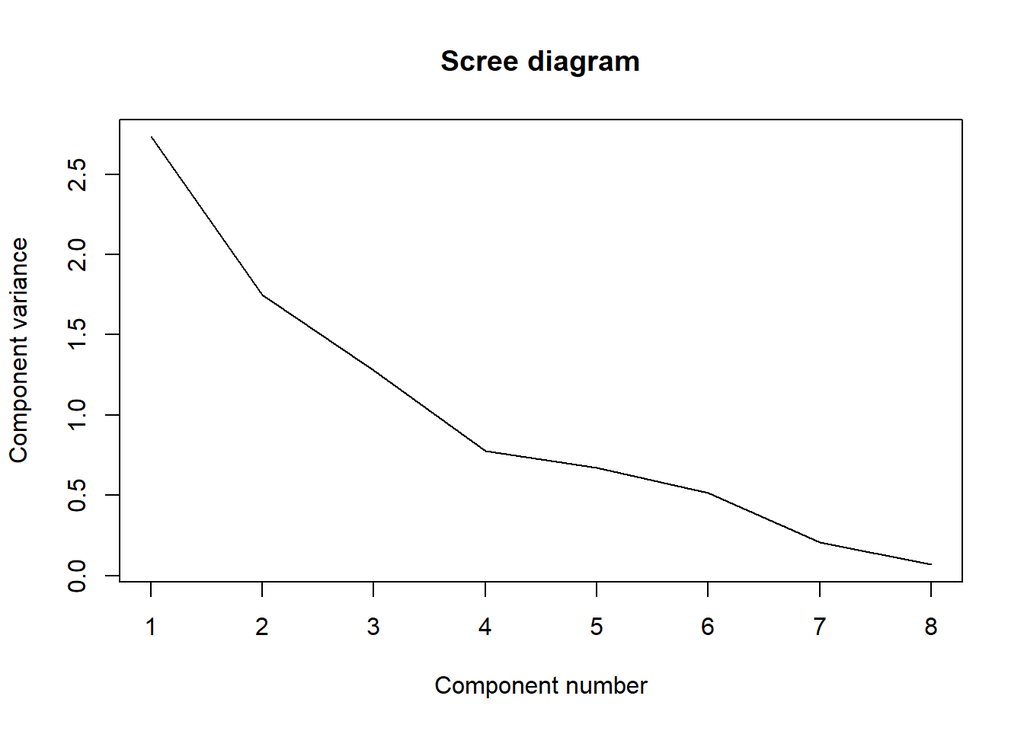

```r
plot(eigen_algaes, xlab = "Component number", ylab = "Component variance", type = "l", main = "Scree diagram")
```

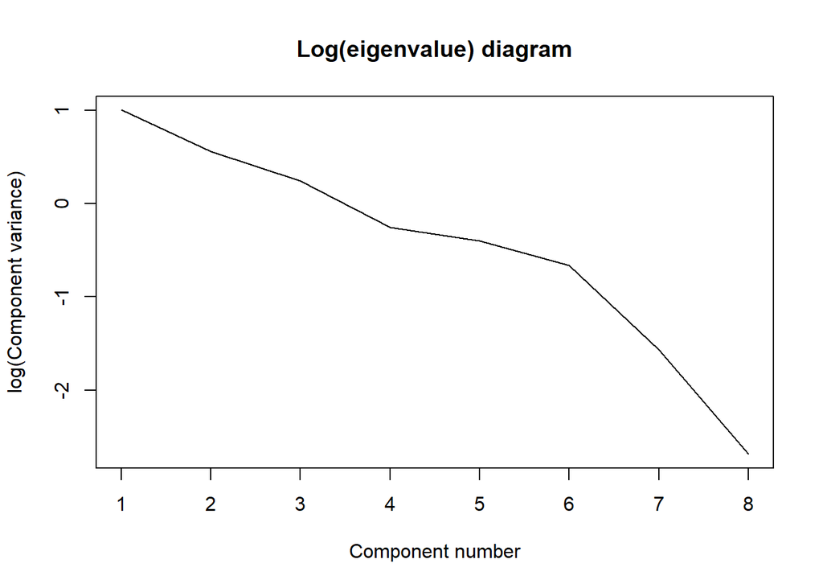

```r
plot(log(eigen_algaes), xlab = "Component number",ylab = "log(Component variance)", type="l",main = "Log(eigenvalue) diagram")
```

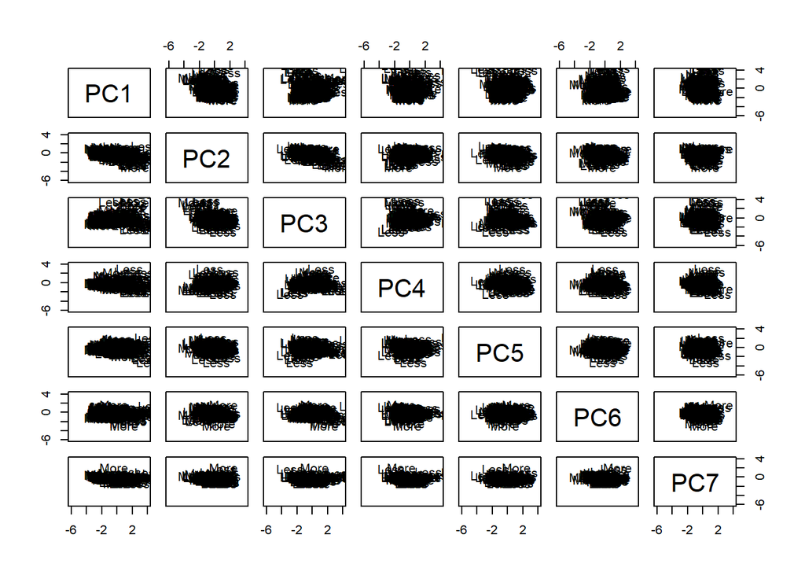

```r
pairs(algae_pca$x[,1:7], ylim = c(-6,4),xlim = c(-6,4),panel=function(x,y,...){text(x,y,algaeDataset$a1Cat)})
```

With this we conclude that PCA is not right fit for this dataset since for the majority of the alage types the principal components are not significant also here we have only considered numerical category data type and not categorical datatype since that would also show some dependancy